Ir al contenido

Ficha actualizada el 5 oct 2026

Ficha del establecimiento · RBD 9416

# Escuela Poetas De Chile

Pedro Aguirre CerdaEscuela BásicaCon Programa de Integración Escolar

Yael Nini Valenzuela Becerra

Dirección del establecimiento

🎒Matrícula

318

−54 respecto de 2025

📅Asistencia promedio

87,5 %

4,7 puntos sobre el promedio del SLEP

📇Estudiantes prioritarios

51,9 %

Concentración declarada (marzo)

📊SIMCE Lectura 4° básico

283 pts

+25 pts respecto del SLEP

¿Primera vez leyendo una ficha?Empieza por la ficha en cifras[Guía para leer los datos (se abre en otra pestaña)](https://datos.slepsantarosa.workers.dev/guia.html)

## La ficha en cifras

Cada cifra enlaza a su sección, donde está explicada y comparada con el SLEP.

📇Estudiantes prioritarios51,9 %Concentración declarada (marzo)Ver sección: Estudiantes prioritarios →

🎒Matrícula318−54 respecto de 2025Ver sección: Matrícula →

📅Asistencia promedio87,5 %4,7 puntos sobre el promedio del SLEPVer sección: Asistencia promedio →

🪑Ocupación de cursos62,4 %318 de 510 cupos declaradosVer sección: Ocupación de cursos →

🤝Estudiantes en el PIE6721,1 % de la matrículaVer sección: Estudiantes en el PIE →

🚶Retiros en 20263410,7 % de la matrículaVer sección: Retiros en 2026 →

📗Aprobación97,4 %Año escolar 2025Ver sección: Aprobación →

📊SIMCE Lectura 4° básico283 pts+25 pts respecto del SLEPVer sección: SIMCE Lectura 4° básico →

🏷️Categoría de desempeñoInsuficienteEducación básica · 2019Ver sección: Categoría de desempeño →

💛Clima de convivencia escolar77,5De 0 a 100 · 2025Ver sección: Clima de convivencia escolar →

🧭Lectura en nivel satisfactorio21,6 %4,5 puntos sobre el promedio del SLEPVer sección: Lectura en nivel satisfactorio →

👥Funcionarios6134 docentes y 27 asistentes de la educaciónVer sección: Funcionarios →

📈Docentes en tramo avanzado o superior44 %12 de 27 con tramo asignadoVer sección: Docentes en tramo avanzado o superior →

📜Acciones del plan de mejoramiento26Plan 2025, en 4 dimensionesVer sección: Acciones del plan de mejoramiento →

⭐SNED 2026-2027No seleccionadoÍndice de 62,9 sobre 100Ver sección: SNED 2026-2027 →

🔗Convenios de uso de espacios2Organizaciones que usan sus espaciosVer sección: Convenios de uso de espacios →

🛡️Denuncias registradas0Ver sección: Denuncias registradas →

🗺️Niños y jóvenes en el barrio3.125De 0 a 17 años, a 800 m a la redondaVer sección: Niños y jóvenes en el barrio →

📍Estudiantes de la misma comuna41 %Viven en Pedro Aguirre CerdaVer sección: Estudiantes de la misma comuna →

Capítulo

¿Qué establecimiento es y qué ofrece?

## 🏫El establecimiento

- 📇Identificación y contacto
- 🎭Vida escolar y participación

El establecimiento · Identificación y contactoDatos al 5 oct 2026

### 📇Identificación y contacto

¿Qué establecimiento es y cómo contactarlo?

Escuela Básica en funcionamiento en Pedro Aguirre Cerda, imparte enseñanza básica, educación parvularia y atiende a 318 estudiantes.

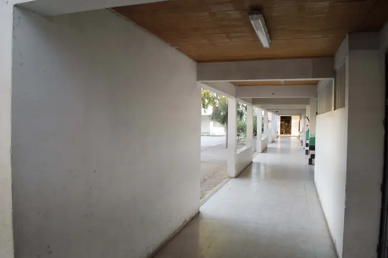

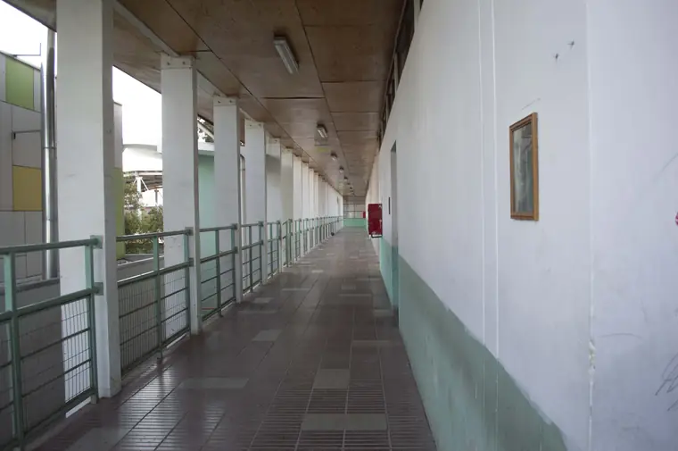

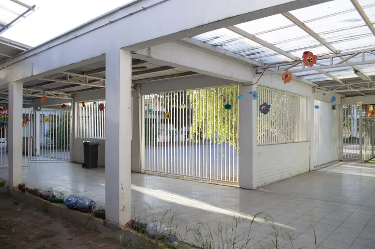

📷Fotografías del establecimiento

Concentración de estudiantes prioritarios

51,9 %

Estudiantes cuya situación socioeconómica puede afectar su rendimiento, según el Ministerio de Educación.

Índice de vulnerabilidad (IVE)

92,8 %

Su comuna: 85,5 %. Lo calcula la JUNAEB y decide a qué establecimientos llegan primero los programas de apoyo.

Cursos en funcionamiento

En enseñanza básica y educación parvularia

Programas y convenios

1

Programa de Integración Escolar

[figure not shown]

👤Dirección del establecimiento

Yael Nini Valenzuela Becerra

✉️escuelapoetasdechile@slepsantarosa.cl

☎️3144748

🤝Asesoría técnica del SLEP: Tamara Roa Cares

📍Dónde queda

Juan Bastias 2890, Pedro Aguirre Cerda.

[interactive chart not shown]

Fuente: Coordenadas del directorio consolidado · [Abrir en Google Maps](https://www.google.com/maps/search/?api=1&query=-33.480737,-70.660476)

#### Identificación

**RBD**

9416-1

**Tipo de establecimiento**

Escuela Básica

**Dependencia**

Servicio Local de Educación Pública Santa Rosa

**Estado**

Funcionando

**Comuna**

Pedro Aguirre Cerda

#### Cómo contactarlo

**Dirección**

Juan Bastias 2890

**Teléfono**

3144748

**Correo**

escuelapoetasdechile@slepsantarosa.cl

#### Equipo y apoyo técnico

**Dirección**

Yael Nini Valenzuela Becerra

**Unidad Técnico Pedagógica**

utp.escuelapoetasdechile@slepsantarosa.cl

**Inspectoría**

inspectoria.escuelapoetasdechile@slepsantarosa.cl

**Asesoría técnica del SLEP**

Tamara Roa Cares

#### Programas y convenios vigentes

Programa de Integración Escolar (PIE)Sin PACE

#### Apoyos profesionales al aprendizaje

ReforzamientoPsicopedagogíaPsicologíaProfesor o profesora de educación especialTrabajo socialFonoaudiologíaOrientaciónOrientación vocacional

#### Necesidades educativas que atiende

Tipos de necesidades educativas especiales que el establecimiento declara atender.

Discapacidad visualDiscapacidad auditivaDiscapacidad intelectualDiscapacidad motoraTrastorno del espectro autistaTrastornos de la comunicaciónDificultades de aprendizajeTrastorno específico del lenguajeDéficit atencionalFuncionamiento intelectual limítrofe

#### Infraestructura declarada

Biblioteca (CRA)Sala de usos múltiplesComputación con internetCancha deportivaGimnasio techadoAccesibilidad para NEELaboratorio de cienciasSala audiovisual

#### Documentos públicos

[Proyecto Educativo Institucional (PEI)](https://wwwfs.mineduc.cl/Archivos/infoescuelas/documentos/9416/ProyectoEducativo9416.pdf)[Reglamento de convivencia](https://wwwfs.mineduc.cl/Archivos/infoescuelas/documentos/9416/ReglamentodeConvivencia9416.pdf)[Reglamento de evaluación](https://wwwfs.mineduc.cl/Archivos/infoescuelas/documentos/9416/ReglamentoDeEvaluacion9416.pdf)

**¿Cómo se lee este dato?**

**Qué es**

La identificación oficial del establecimiento y las vías para comunicarse con él.

**De dónde sale**

Del directorio consolidado que el equipo actualiza cada mes con el registro oficial del Ministerio de Educación y los datos del propio Servicio Local.

**Cómo leerlo**

El **RBD** es el número con que el Ministerio identifica a cada establecimiento: sirve para buscarlo en cualquier sistema público. **Dependencia** indica quién lo administra; desde el traspaso, es el Servicio Local de Educación Pública.

**Referencia**

La **concentración de estudiantes prioritarios** es el porcentaje de estudiantes cuya situación socioeconómica puede dificultar su trayectoria escolar; el Ministerio la usa para asignar la subvención escolar preferencial.

**Lo que no dice**

Que un establecimiento tenga más programas no significa mejores resultados: son convenios a los que se postula según su proyecto y su matrícula.

**Para saber más**

[Guía para leer los datos: Cómo leer una ficha (se abre en otra pestaña)](https://datos.slepsantarosa.workers.dev/guia.html#empezar)

El establecimiento · Vida escolar y participación

### 🎭Vida escolar y participación

¿Quiénes participan en la comunidad educativa?

El establecimiento tiene centro de padres y apoderados, con personalidad jurídica vigente y cuenta con centro de estudiantes.

Centro de padres

Constituido

Personalidad jurídica: vigente

Centro de estudiantes

Constituido

Lo integran estudiantes del establecimiento

Consejo escolar

Con representante del sostenedor

Bruno Cortés González

#### Centro de padres y apoderados

**Personalidad jurídica**

Vigente

**Certificado de directorio vigente**

DPJ_ESCUELA POETAS DE CHILE.pdf

**Última elección del directorio**

**Próxima elección**

Para contactarlo, escribe al establecimiento: sus datos están en «Identificación y contacto».

#### Centro de estudiantes

El establecimiento tiene centro de estudiantes constituido. Lo integran estudiantes del propio establecimiento.

#### Consejo escolar

**Representante del sostenedor**

Bruno Cortés González

**Acompañamiento del SLEP**

Bruno Cortés González

**¿Cómo se lee este dato?**

**Qué es**

Las tres instancias de participación que la ley exige a cada establecimiento: el **consejo escolar** (donde se encuentran dirección, docentes, asistentes, apoderados y estudiantes), el **centro de padres** y el **centro de estudiantes**.

**De dónde sale**

Del registro que mantiene el Servicio Local con los establecimientos, actualizado cuando hay elecciones o cambios de directiva.

**Cómo leerlo**

La **personalidad jurídica** permite al centro de padres administrar recursos propios. Un centro sin directorio vigente no puede firmar convenios ni recibir aportes.

**Lo que no dice**

Que una instancia figure constituida no dice cuán activa es: el registro solo guarda su estado formal.

Capítulo

¿A quiénes educa y cómo avanzan durante el año?

## 🧒Estudiantes

- 🎒Matrícula
- 📅Asistencia
- 🪑Ocupación de cursos
- 🤝Programa de Integración Escolar (PIE)
- 🚶Retiros y traslados

Estudiantes · MatrículaDatos de agosto de 2026

### 🎒Matrícula

¿Cuántos estudiantes tiene y cómo ha cambiado?

En agosto de 2026 estudian 318 estudiantes en el establecimiento, 54 menos que en 2025.

Estudiantes matriculados

318

−54 estudiantes respecto de 2025 (−14,5 %)

82

SLEP 300318

915Rango de los establecimientos del SLEP

Estudiantes por curso

10,5

50,9Rango de los establecimientos del SLEP

Estudiantes extranjeros

37,4 %

119 de 318 estudiantes

6,5 %

SLEP 29,8 %37,4 %

77,6 %Rango de los establecimientos del SLEP

La matrícula bajó 14,5 % en el último año

Estudiantes matriculados en agosto de cada año, según el registro mensual del SIGE.

[interactive chart not shown]

Fuente: SIGE, MINEDUC.

**¿Cómo se lee este dato?**

**Qué es**

La cantidad de estudiantes inscritos en el establecimiento en el mes de corte.

**De dónde sale**

Del Sistema de Información General de Estudiantes (SIGE), que cada establecimiento actualiza mes a mes.

**Cómo leerlo**

Mira la tendencia de varios años antes que un mes aislado: la matrícula se mueve todo el año por traslados, retiros y nuevas incorporaciones.

**Lo que no dice**

Que un establecimiento tenga más estudiantes no significa que enseñe mejor: el tamaño depende de la infraestructura, de los cupos declarados y del barrio.

**Para saber más**

[Guía para leer los datos: Matrícula (se abre en otra pestaña)](https://datos.slepsantarosa.workers.dev/guia.html#matricula)

**Ver la matrícula curso por curso (14 cursos)**

Matrícula por curso

| Curso | Estudiantes | % del total |
| --- | --- | --- |
| Pre-kínder A | 29 | 9,1 % |
| Kínder A | 19 | 6,0 % |
| 1° Básico A | 28 | 8,8 % |
| 1° Básico B | 14 | 4,4 % |
| 2° Básico A | 25 | 7,9 % |
| 2° Básico B | 12 | 3,8 % |
| 3° Básico A | 29 | 9,1 % |
| 4° Básico A | 26 | 8,2 % |
| 4° Básico B | 16 | 5,0 % |
| 5° Básico A | 31 | 9,7 % |
| 6° Básico A | 23 | 7,2 % |
| 6° Básico B | 15 | 4,7 % |
| 7° Básico A | 24 | 7,5 % |
| 8° Básico A | 27 | 8,5 % |

Estudiantes · AsistenciaDatos de agosto de 2026

### 📅Asistencia

¿Cuántos estudiantes van a clases todos los días?

De marzo a agosto de 2026, los estudiantes asistieron en promedio 87,5 % de los días con clases: 4,7 puntos sobre el promedio del SLEP (82,8 %).

Asistencia promedio del año

87,5 %

+2,0 puntos respecto de 2025

49,4 %

SLEP 82,8 %87,5 %

90,4 %Rango de los establecimientos del SLEP

Asistencia de agosto

87,4 %

318 estudiantes en 14 cursos

49,3 %

SLEP 83,6 %87,4 %

93,4 %Rango de los establecimientos del SLEP

Curso con menor asistencia

83,7 %

Kínder A · 3,8 puntos bajo el promedio del establecimiento

1 de 6 meses quedan bajo el 85 %, el más bajo en julio

Asistencia promedio del establecimiento en cada mes de 2026, ponderada por la matrícula de cada curso.

[interactive chart not shown]

Fuente: SIGE, MINEDUC.

**¿Cómo se lee este dato?**

**Qué es**

La proporción entre los días que un estudiante va a clases y los días que hubo clases. La asistencia de un curso o de un establecimiento es el promedio de esos porcentajes.

**De dónde sale**

El establecimiento registra la asistencia todos los días y la declara cada mes en el Sistema de Información General de Estudiantes (SIGE). Esa misma asistencia es la base de la subvención.

**Cómo leerlo**

Compara cada mes con el mismo mes del año anterior: marzo y diciembre se leen distinto por el ingreso escalonado y el cierre del año.

**Referencia**

El Decreto 67 de 2018 exige al menos 85 % de asistencia en el año para ser promovido, con excepciones que autoriza la dirección. El Centro de Estudios del Ministerio usa cuatro categorías: destacada (97 % o más), normal (90 a 97 %), inasistencia reiterada (85 a 90 %) e inasistencia grave (85 % o menos).

**Lo que no dice**

Cuántos estudiantes faltan mucho. Un promedio alto puede esconder a varios estudiantes bajo el 85 %: para saberlo hay que mirar caso a caso, no el promedio.

**Para saber más**

[Guía para leer los datos: Asistencia (se abre en otra pestaña)](https://datos.slepsantarosa.workers.dev/guia.html#asistencia)

**Ver la asistencia curso por curso (14 cursos)**

Asistencia por curso, marzo a agosto de 2026

| Curso | Estudiantes | Asistencia del año | Situación |
| --- | --- | --- | --- |
| Pre-kínder A | 29 | 84,0 % | Bajo el umbral |
| Kínder A | 21 | 83,7 % | Bajo el umbral |
| 1° Básico A | 28 | 86,7 % | Sobre el umbral |
| 1° Básico B | 13 | 84,1 % | Bajo el umbral |
| 2° Básico A | 24 | 85,8 % | Sobre el umbral |
| 2° Básico B | 12 | 89,7 % | Sobre el umbral |
| 3° Básico A | 32 | 88,4 % | Sobre el umbral |
| 4° Básico A | 26 | 89,2 % | Sobre el umbral |
| 4° Básico B | 17 | 90,8 % | Sobre el umbral |
| 5° Básico A | 32 | 89,9 % | Sobre el umbral |
| 6° Básico A | 22 | 88,7 % | Sobre el umbral |
| 6° Básico B | 15 | 89,4 % | Sobre el umbral |
| 7° Básico A | 24 | 88,9 % | Sobre el umbral |
| 8° Básico A | 27 | 86,2 % | Sobre el umbral |

Estudiantes · Ocupación de cursosDatos de agosto de 2026

### 🪑Ocupación de cursos

¿Cuántos cupos están ocupados en cada curso?

En agosto de 2026, 318 estudiantes ocupan los 510 cupos que el establecimiento declaró al Sistema de Admisión Escolar (SAE): 62,4 % de ocupación, con 192 cupos disponibles.

Ocupación de los cupos declarados

62,4 %

318 estudiantes en 510 cupos

33,3 %

SLEP 68,3 %62,4 %

111,2 %Rango de los establecimientos del SLEP

Cursos sobre su capacidad declarada

0

de 14 cursos con cupos declarados

Cupos disponibles

192

repartidos en 14 cursos

Quedan 192 cupos disponibles, repartidos en 14 cursos

Estudiantes matriculados en agosto de 2026 (barra azul) sobre los cupos que el establecimiento declaró al SAE (barra gris).

[interactive chart not shown]

Fuente: SIGE y Sistema de Admisión Escolar, MINEDUC.

**¿Cómo se lee este dato?**

**Qué es**

La ocupación compara los estudiantes efectivamente matriculados en cada curso con los cupos que el establecimiento declaró al Sistema de Admisión Escolar (SAE).

**De dónde sale**

Los cupos los declara el propio establecimiento en el proceso del SAE; la matrícula sale del registro mensual del SIGE. Las dos cifras viajan en la misma tabla, curso por curso.

**Cómo leerlo**

El 100 % significa que todos los cupos declarados están tomados. Pasar del 100 % quiere decir que hay más estudiantes que cupos: casi siempre es señal de que la capacidad declarada al SAE quedó desactualizada, no de que sobren estudiantes en la sala.

**Referencia**

No hay un umbral oficial: la referencia es la capacidad declarada (100 %). Entre los 53 establecimientos del SLEP que declaran cupos, la ocupación va de 33,3 % a 111,2 %, con un promedio de 68,3 %.

**Lo que no dice**

Cuánto espacio físico real tiene el establecimiento. Un curso puede aparecer con cupos libres porque se reservaron vacantes para el SAE o porque la capacidad declarada es mayor que la que se usa.

**Para saber más**

[Guía para leer los datos: Matrícula (se abre en otra pestaña)](https://datos.slepsantarosa.workers.dev/guia.html#matricula)

**Ver los cupos curso por curso (14 cursos)**

Cupos declarados y matrícula por curso, agosto de 2026

| Curso | Estudiantes | Cupos declarados | Ocupación | Cupos disponibles |
| --- | --- | --- | --- | --- |
| Pre-kínder A | 29 | 30 | 96,7 % | 1 |
| Kínder A | 19 | 30 | 63,3 % | 11 |
| 1° Básico A | 28 | 38 | 73,7 % | 10 |
| 1° Básico B | 14 | 38 | 36,8 % | 24 |
| 2° Básico A | 25 | 38 | 65,8 % | 13 |
| 2° Básico B | 12 | 38 | 31,6 % | 26 |
| 3° Básico A | 29 | 38 | 76,3 % | 9 |
| 4° Básico A | 26 | 38 | 68,4 % | 12 |
| 4° Básico B | 16 | 38 | 42,1 % | 22 |
| 5° Básico A | 31 | 38 | 81,6 % | 7 |
| 6° Básico A | 23 | 38 | 60,5 % | 15 |
| 6° Básico B | 15 | 38 | 39,5 % | 23 |
| 7° Básico A | 24 | 35 | 68,6 % | 11 |
| 8° Básico A | 27 | 35 | 77,1 % | 8 |

Estudiantes · PIEDatos de abril de 2026

### 🤝Programa de Integración Escolar (PIE)

¿Cuántos estudiantes reciben apoyos del Programa de Integración Escolar?

67 estudiantes reciben apoyos del Programa de Integración Escolar: 21,1 % de la matrícula, 2,3 puntos sobre el promedio del SLEP (18,8 %).

Estudiantes en el PIE

67

de 318 estudiantes matriculados en agosto de 2026

3

SLEP 5367

140Rango de los establecimientos del SLEP

Porcentaje de la matrícula

21,1 %

+2,3 puntos respecto del promedio del SLEP (18,8 %)

1,7 %

SLEP 18,8 %21,1 %

34,2 %Rango de los establecimientos del SLEP

Diagnóstico más frecuente

25estudiantes

Dificultades del aprendizaje · 37 % de quienes están en el PIE

El PIE bajó de 116 a 101 estudiantes entre 2024 y 2026

Estudiantes con necesidades educativas especiales registrados cada año por el Área de Inclusión Educativa del SLEP. Es un catastro distinto de la nómina del SIGE que alimenta las cifras clave, por eso los totales no coinciden exactamente.

[interactive chart not shown]

Fuente: PIE Territorial, Área de Inclusión Educativa del SLEP Santa Rosa.

**¿Cómo se lee este dato?**

**Qué es**

El Programa de Integración Escolar (PIE) entrega apoyos adicionales —profesionales de apoyo, horas de trabajo conjunto con los docentes y materiales— a los estudiantes que tienen una necesidad educativa especial (NEE) diagnosticada, dentro de la misma sala de clases.

**De dónde sale**

El detalle por estudiante sale de la nómina PIE del SIGE (abril de 2026) y la serie por año, del catastro del Área de Inclusión Educativa del SLEP. Son dos registros distintos, con fechas distintas: sus totales no calzan exactamente.

**Cómo leerlo**

Una necesidad «permanente» acompaña a la persona durante toda su vida —por ejemplo una discapacidad intelectual, sensorial o motora— y da derecho a apoyos en toda la trayectoria escolar. Una necesidad «transitoria» se presenta en un período de la escolaridad y se espera que se supere con apoyo, como las dificultades del aprendizaje o del lenguaje. En la mayoría de los establecimientos las transitorias son las más numerosas.

**Referencia**

En el SLEP Santa Rosa el promedio es 18,8 % de la matrícula. El programa se rige por el Decreto 170 del Ministerio de Educación, que define qué diagnósticos puede atender y qué apoyos financia.

**Lo que no dice**

Un porcentaje alto de estudiantes en el PIE no es un mal resultado: habla de cuántos estudiantes tienen apoyos reconocidos y financiados, no de cómo enseña el establecimiento. Tampoco dice cuántos estudiantes necesitan apoyo, porque solo cuenta a quienes ya tienen un diagnóstico vigente y entraron al programa.

**Ver el detalle por diagnóstico (7 diagnósticos)**

Estudiantes del PIE por diagnóstico

| Diagnóstico | Tipo de necesidad | Estudiantes | % del PIE |
| --- | --- | --- | --- |
| Dificultades del aprendizaje | Transitoria | 25 | 37,3 % |
| Lenguaje (TEL) | Transitoria | 19 | 28,4 % |
| Espectro autista (TEA) | Permanente | 10 | 14,9 % |
| Discapacidad intelectual | Permanente | 5 | 7,5 % |
| Funcionamiento limítrofe | Transitoria | 5 | 7,5 % |
| Déficit atencional (TDA) | Transitoria | 2 | 3,0 % |
| Baja visión | Permanente | 1 | 1,5 % |

Estudiantes · Retiros y trasladosDatos de agosto de 2026

### 🚶Retiros y traslados

¿Cuántos estudiantes se fueron durante el año y por qué?

En 2026 se registraron 34 retiros: 10,7 % de la matrícula, 3,0 puntos bajo el promedio del SLEP (13,7 %).

Retiros registrados en 2026

34

−50 respecto del mismo período de 2025 (84 retiros)

1

SLEP 3934

155Rango de los establecimientos del SLEP

Porcentaje de la matrícula

10,7 %

−3,0 puntos respecto del promedio del SLEP (13,7 %)

0,6 %

SLEP 13,7 %10,7 %

103,3 %Rango de los establecimientos del SLEP

Movimiento más frecuente

22retiros

Traslado fuera del SLEP · 65 % de los retiros del año

Abril y julio son los meses con más retiros: 8 retiros en cada uno

Retiros registrados cada mes de 2026, desde marzo hasta agosto.

[interactive chart not shown]

Fuente: Registro de retiros y traslados del SIGE, MINEDUC.

**¿Cómo se lee este dato?**

**Qué es**

Un retiro es el registro que hace el establecimiento en el SIGE cuando un estudiante deja su curso durante el año escolar. No todos los retiros son iguales: la mayoría son traslados, es decir, el estudiante se matricula en otro establecimiento y sigue estudiando.

**De dónde sale**

Del registro de retiros y traslados del SIGE, cruzado con la matrícula vigente para saber dónde quedó cada estudiante. El corte de estos datos es agosto de 2026.

**Cómo leerlo**

Distingue el «traslado a otro establecimiento» —el estudiante sigue en el sistema escolar, dentro o fuera del SLEP— del «retiro sin matrícula posterior», que es el que conviene mirar de cerca, porque puede anticipar una desvinculación del sistema. Los meses de marzo y diciembre concentran movimientos administrativos —regularizaciones de inicio de año y cierres de curso—, así que un alza en esos meses no significa lo mismo que un alza en mitad del año.

**Referencia**

En el SLEP Santa Rosa los retiros equivalen en promedio a 13,7 % de la matrícula en lo que va de 2026. La comparación se hace con el mismo corte para todos los establecimientos.

**Lo que no dice**

El retiro no es lo mismo que la deserción: solo la matrícula del año siguiente confirma si un estudiante dejó de estudiar. Y como el año todavía no termina, la cifra seguirá subiendo hasta diciembre: no se puede comparar con el total de un año cerrado.

**Para saber más**

[Guía para leer los datos: Matrícula (se abre en otra pestaña)](https://datos.slepsantarosa.workers.dev/guia.html#matricula)

**Ver el detalle mes a mes por tipo de movimiento**

Retiros de 2026 por mes y tipo de movimiento

| Mes del retiro | Fuera del SLEP | Sin matrícula | Dentro del SLEP | Total |
| --- | --- | --- | --- | --- |
| marzo | 4 | 1 | 0 | 5 |
| abril | 3 | 5 | 0 | 8 |
| mayo | 2 | 1 | 1 | 4 |
| junio | 3 | 0 | 0 | 3 |
| julio | 6 | 1 | 1 | 8 |
| agosto | 4 | 1 | 1 | 6 |

**Ver a qué establecimientos se trasladaron (20 establecimientos)**

Establecimientos de destino de los estudiantes trasladados

| Establecimiento de destino | Comuna | Estudiantes |
| --- | --- | --- |
| Escuela General San Martin | Maipú | 3 |
| Colegio Tomas Moro | San Miguel | 2 |
| Escuela Basica Galvarino Valenzuela Moraga | Lolol | 2 |
| Escuela Particular Tte.dagoberto Godoy | La Granja | 2 |
| Colegio Part. Antonio Acevedo Hernandez | Pedro Aguirre Cerda | 1 |
| Colegio Particular María Auxiliadora De Santiago | Santiago | 1 |
| Colegio Particular Padre Fidel Abarca | Pedro Aguirre Cerda | 1 |
| Colegio Santa Rosa | San Miguel | 1 |
| Colegio Teniente Dagoberto Godoy | El Bosque | 1 |
| Escuela Basica San Sebastian De Batuco | Lampa | 1 |
| Escuela Básica Barros Luco Y Especial De Lenguaje | San Miguel | 1 |
| Escuela De Párvulos Rayito De Luz | Pedro Aguirre Cerda | 1 |
| Escuela Llano Subercaseaux | San Miguel | 1 |
| Escuela Particular Pio Doce | Pedro Aguirre Cerda | 1 |
| Escuela Particular Rocio De Los Angeles | Pedro Aguirre Cerda | 1 |
| Escuela Republica De Mexico | Valparaíso | 1 |
| Escuela Teniente Hernan Merino Correa | Pudahuel | 1 |
| Escuela Union Nacional Arabe | Peñalolén | 1 |
| Liceo Araucanía | San Ramón | 1 |
| Liceo Jose Toribio Medina | Ñuñoa | 1 |

Capítulo

¿Qué están aprendiendo sus estudiantes?

## 📚Aprendizajes

- 📗Rendimiento
- 📊SIMCE
- 🏷️Categoría de desempeño
- 💛Desarrollo personal y social
- 🧭Diagnóstico Integral de Aprendizajes (DIA)

Aprendizajes · RendimientoDatos de año escolar 2025

### 📗Rendimiento

¿Cuántos estudiantes aprobaron el año?

En 2025, 97,4 % de los estudiantes que terminaron el año fue promovido de curso, 0,9 puntos por sobre que el promedio del SLEP.

Estudiantes promovidos

97,4 %

+0,9 puntos respecto de 2024

49,7 %

SLEP 96,5 %97,4 %

100,0 %Rango de los establecimientos del SLEP

Nota promedio del establecimiento

5,7

Promedio general de todos los cursos

5,4

SLEP 5,95,7

6,3Rango de los establecimientos del SLEP

Reprobados por inasistencia

0

De 8 estudiantes reprobados en 2025

La aprobación se mantiene estable

Porcentaje de estudiantes promovidos sobre los que terminaron el año en el establecimiento (no incluye retirados ni trasladados).

[interactive chart not shown]

Fuente: Actas de rendimiento, SIGE.

**¿Cómo se lee este dato?**

**Qué es**

El resultado del año escolar de cada estudiante: promovido al curso siguiente o reprobado.

**De dónde sale**

De las actas de rendimiento que el establecimiento entrega al Ministerio al cerrar el año, a través del SIGE.

**Cómo leerlo**

La aprobación se calcula sobre quienes **terminaron el año** en el establecimiento. Los estudiantes **retirados** o **trasladados** se cuentan aparte (sección Retiros y traslados), porque su resultado final lo registra otro establecimiento.

**Referencia**

Un estudiante puede reprobar por notas o por asistencia inferior al 85 % sin justificación aceptada por la dirección.

**Lo que no dice**

Una aprobación de 100 % no significa por sí sola que todos aprendieron lo esperado: para eso están los resultados del SIMCE y del DIA.

**Para saber más**

[Guía para leer los datos: Rendimiento (se abre en otra pestaña)](https://datos.slepsantarosa.workers.dev/guia.html#rendimiento)

**Ver el detalle por curso**

Rendimiento por curso

| Curso | Evaluados | Promovidos | Reprobados | Aprobación | Nota promedio |
| --- | --- | --- | --- | --- | --- |
| 1° Básico | 36 | 35 | 1 | 97,2 % | 6,0 |
| 2° Básico | 37 | 36 | 1 | 97,3 % | 5,8 |
| 3° Básico | 60 | 55 | 5 | 91,7 % | 5,6 |
| 4° Básico | 35 | 34 | 1 | 97,1 % | 5,5 |
| 5° Básico | 42 | 42 | 0 | 100,0 % | 5,9 |
| 6° Básico | 28 | 28 | 0 | 100,0 % | 6,0 |
| 7° Básico | 34 | 34 | 0 | 100,0 % | 5,5 |
| 8° Básico | 35 | 35 | 0 | 100,0 % | 5,5 |

Aprendizajes · SIMCEDatos de 2025

### 📊SIMCE

¿Cómo les fue en las pruebas nacionales SIMCE?

En 2025, 4° básico obtuvo 283 pts en Lectura, 25 puntos por sobre el promedio del SLEP.

Lectura · 4° básico

283 pts

−5 pts respecto de 2024

200

SLEP 258283

314Rango de los establecimientos del SLEP

Matemática · 4° básico

262 pts

+20 pts respecto de 2024

199

SLEP 241262

290Rango de los establecimientos del SLEP

Lectura · 8° básico

215 pts

+1 pts respecto de 2019

175

SLEP 217215

258Rango de los establecimientos del SLEP

Evolución de los puntajes en 4° básico

Puntaje promedio del establecimiento en cada aplicación del SIMCE. No hubo SIMCE en 2020 ni 2021.

[interactive chart not shown]

Fuente: Agencia de Calidad de la Educación.

Para 2025 la Agencia de Calidad publicó los puntajes pero no cuántos estudiantes rindieron la prueba en este establecimiento. Por eso los promedios del SLEP de ese año son simples, no ponderados por matrícula evaluada.

**¿Cómo se lee este dato?**

**Qué es**

El SIMCE es la prueba nacional que aplica la Agencia de Calidad para saber qué aprendieron los estudiantes en Lectura, Matemática y, en algunos años, Ciencias.

**De dónde sale**

De los resultados oficiales que publica la Agencia de Calidad de la Educación por establecimiento y grado.

**Cómo leerlo**

Un puntaje aislado dice poco: compáralo con el promedio del SLEP (la barra de cada tarjeta) y con los años anteriores del mismo curso. Los estándares —**Insuficiente**, **Elemental** y **Adecuado**— dicen cuántos estudiantes alcanzaron lo esperado, que suele ser más informativo que el promedio.

**Referencia**

Diferencias menores a 5 puntos entre años no son significativas: dependen de qué estudiantes rindieron la prueba ese año.

**Lo que no dice**

El SIMCE no mide todo lo que hace una escuela: no evalúa artes, deportes, convivencia ni el progreso individual de cada estudiante.

**Para saber más**

[Guía para leer los datos: SIMCE (se abre en otra pestaña)](https://datos.slepsantarosa.workers.dev/guia.html#simce)

**Ver todos los resultados**

Resultados SIMCE por año, curso y asignatura

| Año | Curso | Asignatura | Puntaje | Evaluados |
| --- | --- | --- | --- | --- |
| 2025 | 4° básico | Lectura | 283 | sin dato |
| 2025 | 4° básico | Matemática | 262 | sin dato |
| 2025 | 8° básico | Lectura | 215 | sin dato |
| 2025 | 8° básico | Matemática | 238 | sin dato |
| 2024 | 4° básico | Lectura | 288 | 36 |
| 2024 | 4° básico | Matemática | 242 | 34 |
| 2024 | 6° básico | Lectura | 226 | 32 |
| 2024 | 6° básico | Matemática | 226 | 30 |
| 2023 | 4° básico | Lectura | 297 | 35 |
| 2023 | 4° básico | Matemática | 244 | 38 |
| 2022 | 4° básico | Lectura | 262 | 41 |
| 2022 | 4° básico | Matemática | 229 | 41 |
| 2019 | 8° básico | Historia y Ciencias Sociales | 222 | 23 |
| 2019 | 8° básico | Lectura | 214 | 22 |
| 2019 | 8° básico | Matemática | 216 | 21 |
| 2018 | 4° básico | Lectura | 250 | 27 |
| 2018 | 4° básico | Matemática | 222 | 28 |
| 2018 | 6° básico | Ciencias Naturales | 185 | 19 |
| 2018 | 6° básico | Lectura | 212 | 19 |
| 2018 | 6° básico | Matemática | 216 | 19 |
| 2017 | 4° básico | Lectura | 236 | 17 |
| 2017 | 4° básico | Matemática | 229 | 17 |
| 2016 | 4° básico | Lectura | 258 | 17 |
| 2016 | 4° básico | Matemática | 244 | 17 |
| 2016 | 6° básico | Historia y Ciencias Sociales | 204 | 20 |
| 2016 | 6° básico | Lectura | 203 | 20 |
| 2016 | 6° básico | Matemática | 216 | 20 |

Aprendizajes · Categoría de desempeñoDatos de 2019

### 🏷️Categoría de desempeño

¿Cómo clasifica la Agencia de Calidad a este establecimiento?

En 2019 la Agencia de Calidad clasificó al establecimiento como Insuficiente en educación básica.

La Agencia de Calidad ordena a todos los establecimientos del país en cuatro categorías. No mira solo el SIMCE: combina los puntajes con los indicadores de desarrollo personal y social, con el contexto socioeconómico de los estudiantes y con cuánto avanzó el establecimiento respecto de sí mismo. La categoría define qué apoyo recibe del Estado.

Educación básica

Insuficiente

En 2018 era medio-bajo.

Cómo ha cambiado la clasificación

Categoría asignada en cada año con clasificación publicada. El color del punto repite la categoría: verde Alto, azul Medio, amarillo Medio-bajo, rojo Insuficiente.

[interactive chart not shown]

Fuente: Agencia de Calidad de la Educación.

#### El historial completo

Categoría de desempeño por año y nivel

| Año | Nivel | Categoría |
| --- | --- | --- |
| 2019 | Básica | Insuficiente |
| 2018 | Básica | Medio-bajo |
| 2017 | Básica | Medio-bajo |
| 2016 | Básica | Medio-bajo |

La última clasificación en las bases del equipo es de 2019. Mientras la Agencia no publique una nueva, esa sigue siendo la categoría vigente del establecimiento.

**¿Cómo se lee este dato?**

**Qué es**

La clasificación oficial que la Agencia de Calidad hace de cada establecimiento del país, una vez al año.

**De dónde sale**

De las ordenaciones que publica la Agencia de Calidad de la Educación, por establecimiento y nivel de enseñanza.

**Cómo leerlo**

Las cuatro categorías, de mayor a menor, son **Alto**, **Medio**, **Medio-bajo** e **Insuficiente**. Se comparan establecimientos de contexto socioeconómico parecido, así que la categoría no es lo mismo que el puntaje SIMCE: una escuela puede tener puntajes bajos y aun así quedar en Medio si avanza más que las escuelas con las que se la compara.

**Referencia**

Las categorías **Medio-bajo** e **Insuficiente** obligan a la Agencia a acompañar al establecimiento con apoyo técnico. Mantenerse en Insuficiente durante cuatro años seguidos puede terminar en la pérdida del reconocimiento oficial.

**Lo que no dice**

La categoría no mide el trabajo de un profesor ni de un curso: es del establecimiento completo y se calcula con datos de varios años, así que refleja una trayectoria, no el año en curso.

**Para saber más**

[Guía para leer los datos: Categoría de Desempeño (se abre en otra pestaña)](https://datos.slepsantarosa.workers.dev/guia.html#categoria-desempeno)

Aprendizajes · Desarrollo personal y socialDatos de 2025

### 💛Desarrollo personal y social

¿Cómo se sienten los estudiantes en su establecimiento?

Entre 2016 y 2025 la Agencia midió estos indicadores 8 veces. El mayor cambio de la última fue hábitos de vida saludable, que bajó 5,0 puntos respecto de 2024 (de 80,0 a 75,0 de 100).

Autoestima académica y motivación escolar

73,5de 100

3,5 puntos más que en 2024

Igual que el contexto similar

Clima de convivencia escolar

77,5de 100

2,5 puntos más que en 2024

Sobre el contexto similar

Participación y formación ciudadana

79,5de 100

0,5 puntos más que en 2024

Sobre el contexto similar

Hábitos de vida saludable

75,0de 100

5,0 puntos menos que en 2024

Sobre el contexto similar

Cómo cambió cada indicador entre 2016 y 2025

Puntaje promedio del establecimiento en cada aplicación, de 0 a 100. Años con datos: 2016, 2017, 2018, 2019, 2022, 2023, 2024 y 2025. No hubo medición en 2020 y 2021. El eje vertical va de 55 a 85 puntos, no parte en cero, para que se vea el movimiento.

[interactive chart not shown]

Fuente: Agencia de Calidad de la Educación · cuestionarios SIMCE.

En 2025, lo más alto fue participación y formación ciudadana y lo más bajo, autoestima académica y motivación escolar

Puntaje de 0 a 100. La barra azul es el establecimiento; la gris, el promedio de los establecimientos de contexto socioeconómico similar que usa la Agencia para comparar. En 2025 quedó sobre ese promedio en 3 de los 4 indicadores y igual en 1.

[interactive chart not shown]

Fuente: Agencia de Calidad de la Educación · cuestionarios SIMCE.

**¿Cómo se lee este dato?**

**Qué es**

Cuatro indicadores que miden cómo viven los estudiantes su escuela: autoestima académica y motivación, clima de convivencia, participación y formación ciudadana, y hábitos de vida saludable.

**De dónde sale**

De los cuestionarios que responden estudiantes, familias y docentes junto con el SIMCE. Los calcula la Agencia de Calidad.

**Cómo leerlo**

Van de 0 a 100 y no son notas: 100 sería que todas las respuestas apuntan en la dirección deseada. En el gráfico de evolución, cada línea es un indicador y su color lo identifica; el eje vertical está recortado al rango de los datos para que el movimiento se vea, y se corta en los años sin aplicación. En el gráfico del último año el color dice quién es, no si el resultado es bueno: azul el establecimiento, gris el promedio de establecimientos de contexto socioeconómico similar; la etiqueta de cada tarjeta dice con palabras si el establecimiento quedó sobre, bajo o igual que ese promedio, y una diferencia menor a medio punto se lee como «igual». En 2025 se evaluó más de un curso, así que el puntaje es el promedio de esos cursos y por eso lleva un decimal.

**Referencia**

Estos indicadores pesan un tercio de la Categoría de Desempeño que asigna la Agencia de Calidad. La comparación con establecimientos de contexto similar viene en las bases de 2024 y 2025.

**Lo que no dice**

No miden la convivencia del año en curso: reflejan lo que respondieron las personas el año de la evaluación. Tampoco son un seguimiento de los mismos estudiantes: cada aplicación mide a los cursos que rindieron el SIMCE ese año, que no siempre son los mismos, así que parte del cambio entre años viene de qué cursos se evaluaron.

**Para saber más**

[Guía para leer los datos: Categoría de Desempeño (se abre en otra pestaña)](https://datos.slepsantarosa.workers.dev/guia.html#categoria-desempeno)

**Ver el detalle por año y curso**

Indicadores de desarrollo personal y social

| Año | Curso | Indicador | Puntaje | Contexto similar | Diferencia |
| --- | --- | --- | --- | --- | --- |
| 2025 | 4b | Autoestima académica y motivación escolar | 70,0 | 74,0 | −4 |
| 2025 | 8b | Autoestima académica y motivación escolar | 77,0 | 73,0 | +4 |
| 2025 | 4b | Clima de convivencia escolar | 76,0 | 75,0 | +1 |
| 2025 | 8b | Clima de convivencia escolar | 79,0 | 75,0 | +4 |
| 2025 | 4b | Participación y formación ciudadana | 78,0 | 77,0 | +1 |
| 2025 | 8b | Participación y formación ciudadana | 81,0 | 76,0 | +5 |
| 2025 | 4b | Hábitos de vida saludable | 73,0 | 71,0 | +2 |
| 2025 | 8b | Hábitos de vida saludable | 77,0 | 70,0 | +7 |
| 2024 | 4b | Autoestima académica y motivación escolar | 70,0 | 75,0 | −5 |
| 2024 | 4b | Clima de convivencia escolar | 75,0 | 75,0 | 0 |
| 2024 | 4b | Participación y formación ciudadana | 79,0 | 79,0 | 0 |
| 2024 | 4b | Hábitos de vida saludable | 80,0 | 71,0 | +9 |
| 2023 | 4b | Autoestima académica y motivación escolar | 76,0 | — | — |
| 2023 | 4b | Clima de convivencia escolar | 76,0 | — | — |
| 2023 | 4b | Participación y formación ciudadana | 80,0 | — | — |
| 2023 | 4b | Hábitos de vida saludable | 75,0 | — | — |
| 2022 | 4b | Autoestima académica y motivación escolar | 73,0 | — | — |
| 2022 | 4b | Clima de convivencia escolar | 74,0 | — | — |
| 2022 | 4b | Participación y formación ciudadana | 79,0 | — | — |
| 2022 | 4b | Hábitos de vida saludable | 70,0 | — | — |
| 2019 | 8b | Autoestima académica y motivación escolar | 73,4 | — | — |
| 2019 | 8b | Clima de convivencia escolar | 75,6 | — | — |
| 2019 | 8b | Participación y formación ciudadana | 74,6 | — | — |
| 2019 | 8b | Hábitos de vida saludable | 61,7 | — | — |
| 2018 | 4b | Autoestima académica y motivación escolar | 72,9 | — | — |
| 2018 | 6b | Autoestima académica y motivación escolar | 69,8 | — | — |
| 2018 | 4b | Clima de convivencia escolar | 72,7 | — | — |
| 2018 | 6b | Clima de convivencia escolar | 68,4 | — | — |
| 2018 | 4b | Participación y formación ciudadana | 70,4 | — | — |
| 2018 | 6b | Participación y formación ciudadana | 70,5 | — | — |
| 2018 | 4b | Hábitos de vida saludable | 63,3 | — | — |
| 2018 | 6b | Hábitos de vida saludable | 55,8 | — | — |
| 2017 | 4b | Autoestima académica y motivación escolar | 64,7 | — | — |
| 2017 | 8b | Autoestima académica y motivación escolar | 73,2 | — | — |
| 2017 | 4b | Clima de convivencia escolar | 66,4 | — | — |
| 2017 | 8b | Clima de convivencia escolar | 77,3 | — | — |
| 2017 | 4b | Participación y formación ciudadana | 61,8 | — | — |
| 2017 | 8b | Participación y formación ciudadana | 75,8 | — | — |
| 2017 | 4b | Hábitos de vida saludable | 53,8 | — | — |
| 2017 | 8b | Hábitos de vida saludable | 63,7 | — | — |
| 2016 | 4b | Autoestima académica y motivación escolar | 72,0 | — | — |
| 2016 | 6b | Autoestima académica y motivación escolar | 75,0 | — | — |
| 2016 | 4b | Clima de convivencia escolar | 74,0 | — | — |
| 2016 | 6b | Clima de convivencia escolar | 65,0 | — | — |
| 2016 | 4b | Participación y formación ciudadana | 75,0 | — | — |
| 2016 | 6b | Participación y formación ciudadana | 78,0 | — | — |
| 2016 | 4b | Hábitos de vida saludable | 66,0 | — | — |
| 2016 | 6b | Hábitos de vida saludable | 64,0 | — | — |

Aprendizajes · Diagnóstico Integral de Aprendizajes (DIA)Datos al 29 sep 2026

### 🧭Diagnóstico Integral de Aprendizajes (DIA)

¿Qué aprendizajes lograron durante el año según el DIA?

En el monitoreo intermedio 2026, 21,6 % de los 213 estudiantes evaluados en Lectura quedó en el nivel más bajo (Nivel I, insatisfactorio): 1,2 puntos sobre el promedio del SLEP.

El DIA es una herramienta de la Agencia de Calidad de la Educación que el propio establecimiento aplica, de forma voluntaria y para uso interno, en tres momentos del año: diagnóstico en marzo, monitoreo intermedio en julio y cierre en noviembre. No es una prueba de ranking ni entra en la evaluación oficial del establecimiento: sirve para ver cómo van los estudiantes y ajustar la enseñanza durante el año.

Este establecimiento tiene resultados del DIA en 10 períodos: Monitoreo intermedio 2026, Diagnóstico 2026, Inicio 2026, Cierre 2025, Monitoreo intermedio 2025, Diagnóstico 2025, Inicio 2025, Cierre 2024, Monitoreo intermedio 2024, Diagnóstico 2024. Cada aplicación es una foto propia y se lee por separado.

Lectura en nivel satisfactorio

21,6 %

4,5 puntos sobre el promedio del SLEP

0 %

SLEP 17 %22 %

53 %Rango de los establecimientos del SLEP

Matemática en nivel satisfactorio

8,0 %

5,3 puntos bajo el promedio del SLEP

0 %

SLEP 13 %8 %

44 %Rango de los establecimientos del SLEP

Lectura en nivel insatisfactorio

21,6 %

1,2 puntos sobre el promedio del SLEP

5 %

SLEP 20 %22 %

55 %Rango de los establecimientos del SLEP

NT1: consolidando o profundizando

8,3 %

1,0 puntos bajo el promedio del SLEP

#### Las pruebas por asignatura: cómo le fue a cada grado

En estas pruebas los estudiantes responden preguntas de la asignatura y la Agencia informa cómo queda el grupo. En las pestañas están Lectura, Matemática, Escritura, Historia y Cs. Sociales, Ciencias Naturales. Elige un período en las pestañas.

En Lectura, 57 % de los estudiantes evaluados quedó en el nivel intermedio (Nivel II)

Monitoreo intermedio 2026: cómo se reparten los estudiantes de cada grado entre los niveles de logro, con el total del establecimiento y el promedio del SLEP para la misma prueba y los mismos grados. Áreas evaluadas: Lectura y Matemática y Historia y Cs. Sociales y Ciencias Naturales.

[interactive chart not shown]

Fuente: Agencia de Calidad de la Educación · DIA monitoreo intermedio 2026, aplicado del 7 de julio al 28 de agosto de 2026 (plazo extendido).

En 1 grado evaluado hay menos de 10 estudiantes con resultado (por ejemplo, 9 estudiantes en Lectura de 5° básico, monitoreo intermedio 2024): en grupos así un solo estudiante mueve el porcentaje varios puntos. No todos los períodos evalúan las mismas asignaturas: Diagnóstico 2026 cubre menos asignaturas que el período más completo, así que las pestañas no son directamente comparables entre sí. Las pestañas muestran los 4 períodos más recientes; Diagnóstico 2025, Cierre 2024, Monitoreo intermedio 2024, Diagnóstico 2024 están en las tablas de detalle.

#### Los cuestionarios: qué responden los propios estudiantes

Los cuestionarios del DIA no son pruebas y no tienen respuestas correctas: son afirmaciones que responden los propios estudiantes, en la sala, sobre cómo se sienten y cómo ven su establecimiento. No los responden los apoderados ni los docentes. Aquí los respondieron estudiantes de 4° básico a 8° básico.

El porcentaje que se informa es el de respuestas favorables: las que expresan una percepción positiva de lo que la pregunta plantea. Mientras más alto, más estudiantes del grupo respondieron en ese sentido. Es la percepción del curso en ese momento, no un diagnóstico de cada estudiante. En los temas de ansiedad las preguntas están redactadas al revés a propósito: ahí un porcentaje alto significa menos ansiedad.

#### Condiciones para la formación integral

Lo respondieron 156 estudiantes de 4° básico a 8° básico, en el monitoreo intermedio 2026.

Les pregunta por su bienestar en el establecimiento, cuánta ansiedad les producen las evaluaciones y qué apoyo reciben, y por sus habilidades para convivir en internet.

#### Aprendizaje socioemocional

Lo respondieron 162 estudiantes de 4° básico a 8° básico, en el diagnóstico 2026.

Les pregunta cómo se conocen y se manejan a sí mismos, cómo se relacionan con los demás y cómo participan en la comunidad escolar.

#### Socioemocional (instrumento 2025)

Lo respondieron 166 estudiantes de 4° básico a 8° básico, en el monitoreo intermedio 2025.

Les pregunta por el trabajo en equipo en clases, el vínculo con docentes y compañeros, cómo organizan su propio estudio, la ansiedad frente a las pruebas y el uso responsable de internet.

En Condiciones para la formación integral, los estudiantes responden mejor sobre Bienestar (79 % de respuestas favorables) y más bajo sobre Ansiedad ante las evaluaciones (43 %)

Porcentaje de respuestas favorables de los propios estudiantes en cada tema, junto al promedio de los establecimientos del SLEP en el mismo cuestionario. Cada barra junta las preguntas sobre los estudiantes y las preguntas sobre lo que hace el establecimiento. Aplicaciones más recientes de cada cuestionario: Condiciones para la formación integral (monitoreo intermedio 2026), Aprendizaje socioemocional (diagnóstico 2026), Socioemocional (instrumento 2025) (monitoreo intermedio 2025).

[interactive chart not shown]

Fuente: Agencia de Calidad de la Educación · cuestionarios del DIA respondidos por los estudiantes.

#### DIA de Educación Parvularia: NT1 y NT2

En NT1 y NT2 no hay prueba: la educadora observa a cada niño y niña durante varias semanas y registra en qué nivel de progreso está en cada núcleo de aprendizaje, con las rúbricas que entrega la Agencia.

En NT2 (kínder), 51 % de las evaluaciones por núcleo está en Consolidando o Profundizando

Inicio 2026: cómo se reparten las evaluaciones de cada núcleo de aprendizaje entre los cuatro niveles de progreso, en NT1 y NT2, con el promedio del SLEP. Cada niño o niña es evaluado en todos los núcleos.

[interactive chart not shown]

Fuente: Agencia de Calidad de la Educación · DIA de Educación Parvularia.

**¿Cómo se lee este dato?**

**Qué es**

El Diagnóstico Integral de Aprendizajes (DIA) muestra cómo van los estudiantes en Lectura, Matemática, Escritura, Historia, Ciencias Naturales y en el área socioemocional. Tiene tres partes distintas. Las pruebas por asignatura informan la distribución del curso en tres niveles de logro (Nivel I o insatisfactorio, Nivel II o intermedio, Nivel III o satisfactorio) y el porcentaje de respuestas correctas por eje y habilidad. Los cuestionarios los responden los propios estudiantes, de 4.º básico a IV.º medio —no los apoderados ni los docentes—, y se informan como porcentaje de respuestas favorables por tema; incluyen preguntas sobre ellos mismos y preguntas sobre lo que hace el establecimiento, que también contestan ellos. El DIA de Educación Parvularia no es una prueba: la educadora observa a cada niño y niña y registra su nivel de progreso en cuatro categorías (Comenzando, Desarrollando, Consolidando y Profundizando).

**De dónde sale**

Lo aplica el propio establecimiento con los instrumentos que entrega la Agencia de Calidad de la Educación, en tres momentos: diagnóstico (marzo y abril), monitoreo intermedio (julio y agosto) y cierre (fines de octubre a inicios de diciembre). Las cifras vienen de las bases que procesa el Departamento de Estudios, Monitoreo y Datos del SLEP con los informes de la Agencia, las mismas del Visor DIA del portal.

**Cómo leerlo**

Mira primero cuántos estudiantes rindieron cada aplicación: si en marzo rindieron 28 y en noviembre 22, la comparación pierde fuerza. Después mira la distribución completa, no solo el nivel más alto: dos cursos con el mismo promedio pueden tener proporciones muy distintas en Nivel I. Los ejes y habilidades de la tabla de detalle dicen qué contenidos avanzaron y cuáles no. Lo que responden los estudiantes en los cuestionarios se lee como percepción, no como diagnóstico clínico.

**Referencia**

El promedio del SLEP que aparece junto a cada barra es el resultado de los establecimientos del servicio en la misma prueba, el mismo período y los mismos grados. Es contexto para conversar, no un ranking ni una meta oficial.

**Lo que no dice**

Hasta dónde llega: cada período es una foto propia y no se encadena con los demás. Las únicas comparaciones que respalda la Agencia son monitoreo intermedio contra cierre del mismo año en lo académico, y diagnóstico contra cierre del mismo año en lo socioemocional. El diagnóstico mide los aprendizajes del año anterior; los instrumentos de 2026 cambiaron con el fin de la priorización curricular y no se comparan con 2025; el Cierre 2024 viene agregado por establecimiento; y el DIA de Educación Parvularia no se compara entre años ni entre NT1 y NT2. El DIA tampoco se compara con el SIMCE ni con el DIA de otro establecimiento.

**Para saber más**

[Guía para leer los datos: DIA (se abre en otra pestaña)](https://datos.slepsantarosa.workers.dev/guia.html#dia)

**Ver los niveles de logro período por período (118 filas)**

Niveles de logro del DIA por período, área y grado

| Período | Área y grado | Evaluados | Insatisfactorio | Intermedio | Satisfactorio |
| --- | --- | --- | --- | --- | --- |
| Monitoreo intermedio 2026 | Lectura · 2° básico | 33 | 24,2 % | 51,5 % | 24,2 % |
| Monitoreo intermedio 2026 | Lectura · 3° básico | 29 | 13,8 % | 55,2 % | 31,0 % |
| Monitoreo intermedio 2026 | Lectura · 4° básico | 42 | 31,0 % | 42,9 % | 26,2 % |
| Monitoreo intermedio 2026 | Lectura · 5° básico | 29 | 20,7 % | 41,4 % | 37,9 % |
| Monitoreo intermedio 2026 | Lectura · 6° básico | 35 | 8,6 % | 74,3 % | 17,1 % |
| Monitoreo intermedio 2026 | Lectura · 7° básico | 21 | 9,5 % | 85,7 % | 4,8 % |
| Monitoreo intermedio 2026 | Lectura · 8° básico | 24 | 41,7 % | 58,3 % | 0,0 % |
| Monitoreo intermedio 2026 | Lectura · Total del establecimiento | 213 | 21,6 % | 56,8 % | 21,6 % |
| Monitoreo intermedio 2026 | Matemática · 2° básico | 34 | 0,0 % | 76,5 % | 23,5 % |
| Monitoreo intermedio 2026 | Matemática · 3° básico | 30 | 46,7 % | 46,7 % | 6,7 % |
| Monitoreo intermedio 2026 | Matemática · 4° básico | 40 | 22,5 % | 67,5 % | 10,0 % |
| Monitoreo intermedio 2026 | Matemática · 5° básico | 26 | 57,7 % | 42,3 % | 0,0 % |
| Monitoreo intermedio 2026 | Matemática · 6° básico | 37 | 40,5 % | 54,1 % | 5,4 % |
| Monitoreo intermedio 2026 | Matemática · 7° básico | 20 | 55,0 % | 40,0 % | 5,0 % |
| Monitoreo intermedio 2026 | Matemática · 8° básico | 25 | 92,0 % | 8,0 % | 0,0 % |
| Monitoreo intermedio 2026 | Matemática · Total del establecimiento | 212 | 41,0 % | 50,9 % | 8,0 % |
| Monitoreo intermedio 2026 | Historia y Cs. Sociales · 5° básico | 23 | 43,5 % | 56,5 % | 0,0 % |
| Monitoreo intermedio 2026 | Historia y Cs. Sociales · 6° básico | 34 | 70,6 % | 29,4 % | 0,0 % |
| Monitoreo intermedio 2026 | Historia y Cs. Sociales · 7° básico | 17 | 52,9 % | 47,1 % | 0,0 % |
| Monitoreo intermedio 2026 | Historia y Cs. Sociales · 8° básico | 19 | 52,6 % | 47,4 % | 0,0 % |
| Monitoreo intermedio 2026 | Historia y Cs. Sociales · Total del establecimiento | 93 | 57,0 % | 43,0 % | 0,0 % |
| Monitoreo intermedio 2026 | Ciencias Naturales · 5° básico | 26 | 26,9 % | 73,1 % | 0,0 % |
| Monitoreo intermedio 2026 | Ciencias Naturales · 6° básico | 33 | 33,3 % | 66,7 % | 0,0 % |
| Monitoreo intermedio 2026 | Ciencias Naturales · 7° básico | 21 | 57,1 % | 42,9 % | 0,0 % |
| Monitoreo intermedio 2026 | Ciencias Naturales · 8° básico | 24 | 91,7 % | 8,3 % | 0,0 % |
| Monitoreo intermedio 2026 | Ciencias Naturales · Total del establecimiento | 104 | 50,0 % | 50,0 % | 0,0 % |
| Cierre 2025 | Lectura · 2° básico | 23 | 8,7 % | 56,5 % | 34,8 % |
| Cierre 2025 | Lectura · 3° básico | 46 | 0,0 % | 47,8 % | 52,2 % |
| Cierre 2025 | Lectura · 4° básico | 22 | 13,6 % | 31,8 % | 54,5 % |
| Cierre 2025 | Lectura · 5° básico | 41 | 9,8 % | 73,2 % | 17,1 % |

[output cut: 88 more lines]

**Ver el detalle por eje, habilidad e indicador (706 filas)**

Porcentaje de logro del DIA por eje, habilidad o indicador

| Período | Área y grado | Eje, habilidad o indicador | Este establecimiento | Promedio SLEP |
| --- | --- | --- | --- | --- |
| Monitoreo intermedio 2026 | Lectura · 2° básico | Localizar | 59,1 % | 68,8 % |
| Monitoreo intermedio 2026 | Lectura · 2° básico | Interpretar y relacionar | 62,5 % | 67,8 % |
| Monitoreo intermedio 2026 | Lectura · 2° básico | Reflexionar | 47,0 % | 50,3 % |
| Monitoreo intermedio 2026 | Lectura · 3° básico | Localizar | 59,8 % | 67,2 % |
| Monitoreo intermedio 2026 | Lectura · 3° básico | Interpretar y relacionar | 59,9 % | 67,6 % |
| Monitoreo intermedio 2026 | Lectura · 3° básico | Reflexionar | 37,9 % | 52,6 % |
| Monitoreo intermedio 2026 | Lectura · 4° básico | Localizar | 64,8 % | 67,4 % |
| Monitoreo intermedio 2026 | Lectura · 4° básico | Interpretar y relacionar | 52,1 % | 55,7 % |
| Monitoreo intermedio 2026 | Lectura · 4° básico | Reflexionar | 50,6 % | 50,6 % |
| Monitoreo intermedio 2026 | Lectura · 5° básico | Localizar | 70,1 % | 55,7 % |
| Monitoreo intermedio 2026 | Lectura · 5° básico | Interpretar y relacionar | 66,1 % | 52,0 % |
| Monitoreo intermedio 2026 | Lectura · 5° básico | Reflexionar | 49,1 % | 47,2 % |
| Monitoreo intermedio 2026 | Lectura · 6° básico | Localizar | 73,1 % | 61,5 % |
| Monitoreo intermedio 2026 | Lectura · 6° básico | Interpretar y relacionar | 57,9 % | 52,6 % |
| Monitoreo intermedio 2026 | Lectura · 6° básico | Reflexionar | 48,9 % | 54,8 % |
| Monitoreo intermedio 2026 | Lectura · 7° básico | Localizar | 67,9 % | 61,0 % |
| Monitoreo intermedio 2026 | Lectura · 7° básico | Interpretar y relacionar | 58,1 % | 50,5 % |
| Monitoreo intermedio 2026 | Lectura · 7° básico | Reflexionar | 36,4 % | 41,4 % |
| Monitoreo intermedio 2026 | Lectura · 8° básico | Localizar | 49,0 % | 50,5 % |
| Monitoreo intermedio 2026 | Lectura · 8° básico | Interpretar y relacionar | 47,0 % | 57,3 % |
| Monitoreo intermedio 2026 | Lectura · 8° básico | Reflexionar | 33,7 % | 46,5 % |
| Monitoreo intermedio 2026 | Matemática · 1° básico | Números y operaciones | 79,4 % | 76,7 % |
| Monitoreo intermedio 2026 | Matemática · 1° básico | Patrones y álgebra | 59,3 % | 62,3 % |
| Monitoreo intermedio 2026 | Matemática · 1° básico | Geometría | 89,8 % | 87,7 % |
| Monitoreo intermedio 2026 | Matemática · 1° básico | Medición | 65,3 % | 59,4 % |
| Monitoreo intermedio 2026 | Matemática · 1° básico | Datos y probabilidades | 86,1 % | 78,5 % |
| Monitoreo intermedio 2026 | Matemática · 1° básico | Porcentaje total de respuestas correctas | 77,4 % | 74,8 % |
| Monitoreo intermedio 2026 | Matemática · 2° básico | Números y operaciones | 56,7 % | 66,7 % |
| Monitoreo intermedio 2026 | Matemática · 2° básico | Patrones y álgebra | 85,3 % | 85,7 % |
| Monitoreo intermedio 2026 | Matemática · 2° básico | Geometría | 79,4 % | 85,6 % |

[output cut: 676 more lines]

**Ver lo que respondieron los estudiantes, tema por tema (59 filas)**

Respuestas favorables de los cuestionarios del DIA

| Período | Cuestionario | Dimensión | Estudiantes que respondieron | Este establecimiento | Promedio SLEP |
| --- | --- | --- | --- | --- | --- |
| Monitoreo intermedio 2026 | Condiciones para la formación integral | Bienestar · Experiencias para el bienestar | 156 | 79,0 % | 77,2 % |
| Monitoreo intermedio 2026 | Condiciones para la formación integral | Bienestar · Contexto escolar para el bienestar | 156 | 85,3 % | 80,6 % |
| Monitoreo intermedio 2026 | Condiciones para la formación integral | Ansiedad ante las evaluaciones · Experiencia (un % alto significa menos ansiedad) | 156 | 42,8 % | 40,0 % |
| Monitoreo intermedio 2026 | Condiciones para la formación integral | Ansiedad ante las evaluaciones · Gestión de apoyos | 156 | 64,0 % | 57,0 % |
| Monitoreo intermedio 2026 | Condiciones para la formación integral | Convivencia digital · Gestión del establecimiento | 156 | 76,9 % | 74,3 % |
| Monitoreo intermedio 2026 | Condiciones para la formación integral | Convivencia digital · Desarrollo de las y los estudiantes (7° básico a IV° medio) | 50 | 76,6 % | 79,1 % |
| Diagnóstico 2026 | Aprendizaje socioemocional | Personal · Desarrollo de las y los estudiantes | 162 | 63,7 % | 65,7 % |
| Diagnóstico 2026 | Aprendizaje socioemocional | Personal · Gestión del establecimiento | 162 | 78,4 % | 78,6 % |
| Diagnóstico 2026 | Aprendizaje socioemocional | Comunitario · Desarrollo de las y los estudiantes | 162 | 73,6 % | 74,9 % |
| Diagnóstico 2026 | Aprendizaje socioemocional | Comunitario · Gestión del establecimiento | 162 | 85,5 % | 84,1 % |
| Diagnóstico 2026 | Aprendizaje socioemocional | Ciudadano · Desarrollo de las y los estudiantes | 162 | 76,6 % | 78,1 % |
| Diagnóstico 2026 | Aprendizaje socioemocional | Ciudadano · Gestión del establecimiento | 162 | 87,7 % | 84,9 % |
| Cierre 2025 | Aprendizaje socioemocional | Personal · Desarrollo de las y los estudiantes | 148 | 66,7 % | 65,5 % |
| Cierre 2025 | Aprendizaje socioemocional | Personal · Gestión del establecimiento | 148 | 82,9 % | 76,1 % |
| Cierre 2025 | Aprendizaje socioemocional | Comunitario · Desarrollo de las y los estudiantes | 148 | 77,1 % | 75,0 % |
| Cierre 2025 | Aprendizaje socioemocional | Comunitario · Gestión del establecimiento | 148 | 85,8 % | 79,4 % |
| Cierre 2025 | Aprendizaje socioemocional | Ciudadano · Desarrollo de las y los estudiantes | 148 | 75,7 % | 76,0 % |
| Cierre 2025 | Aprendizaje socioemocional | Ciudadano · Gestión del establecimiento | 148 | 87,3 % | 81,8 % |
| Monitoreo intermedio 2025 | Socioemocional (instrumento 2025) | Promoción del aprendizaje colaborativo | 166 | 76,7 % | 71,9 % |
| Monitoreo intermedio 2025 | Socioemocional (instrumento 2025) | Fortalecimiento del vínculo para el aprendizaje | 166 | 85,7 % | 82,4 % |
| Monitoreo intermedio 2025 | Socioemocional (instrumento 2025) | Apoyo de docentes y pares para la autorregulación académica | 166 | 81,2 % | 77,0 % |
| Monitoreo intermedio 2025 | Socioemocional (instrumento 2025) | Autorregulación del aprendizaje | 166 | 71,2 % | 69,5 % |
| Monitoreo intermedio 2025 | Socioemocional (instrumento 2025) | Ansiedad académica (un % alto significa menos ansiedad) | 166 | 33,0 % | 34,2 % |
| Monitoreo intermedio 2025 | Socioemocional (instrumento 2025) | Ciudadanía digital · Habilidades de las y los estudiantes | 68 | 74,6 % | 75,1 % |
| Monitoreo intermedio 2025 | Socioemocional (instrumento 2025) | Ciudadanía digital · Promoción del establecimiento | 68 | 70,0 % | 68,2 % |
| Diagnóstico 2025 | Aprendizaje socioemocional | Personal · Desarrollo de las y los estudiantes | 118 | 57,8 % | 63,1 % |
| Diagnóstico 2025 | Aprendizaje socioemocional | Personal · Gestión del establecimiento | 118 | 77,5 % | 75,9 % |
| Diagnóstico 2025 | Aprendizaje socioemocional | Comunitario · Desarrollo de las y los estudiantes | 118 | 68,9 % | 73,6 % |
| Diagnóstico 2025 | Aprendizaje socioemocional | Comunitario · Gestión del establecimiento | 118 | 80,3 % | 78,9 % |
| Diagnóstico 2025 | Aprendizaje socioemocional | Ciudadano · Desarrollo de las y los estudiantes | 118 | 73,5 % | 74,9 % |
| Diagnóstico 2025 | Aprendizaje socioemocional | Ciudadano · Gestión del establecimiento | 118 | 85,6 % | 82,8 % |
| Diagnóstico 2025 | Convivencia escolar | Promoción universal · Experiencia en el establecimiento | 117 | 70,1 % | 69,2 % |
| Diagnóstico 2025 | Convivencia escolar | Promoción universal · Convivencia en el curso | 117 | 73,1 % | 67,3 % |
| Diagnóstico 2025 | Convivencia escolar | Promoción universal · Gestión del establecimiento | 117 | 86,0 % | 79,2 % |
| Diagnóstico 2025 | Convivencia escolar | Apoyos focalizados · Experiencia de las y los estudiantes | 117 | 84,0 % | 79,4 % |
| Diagnóstico 2025 | Convivencia escolar | Apoyos focalizados · Gestión del establecimiento | 117 | 89,2 % | 83,1 % |
| Diagnóstico 2025 | Convivencia escolar | Intervenciones de mayor intensidad · Experiencia de las y los estudiantes | 117 | 86,9 % | 78,2 % |
| Diagnóstico 2025 | Convivencia escolar | Intervenciones de mayor intensidad · Gestión del establecimiento | 117 | 87,2 % | 78,9 % |
| Cierre 2024 | Aprendizaje socioemocional | Personal · Desarrollo de las y los estudiantes | 16 | 68,8 % | 66,1 % |
| Cierre 2024 | Aprendizaje socioemocional | Personal · Gestión del establecimiento | 16 | 72,4 % | 71,7 % |
| Cierre 2024 | Aprendizaje socioemocional | Comunitario · Desarrollo de las y los estudiantes | 16 | 78,1 % | 75,1 % |
| Cierre 2024 | Aprendizaje socioemocional | Comunitario · Gestión del establecimiento | 16 | 84,4 % | 81,4 % |
| Cierre 2024 | Aprendizaje socioemocional | Ciudadano · Desarrollo de las y los estudiantes | 16 | 79,7 % | 72,1 % |
| Cierre 2024 | Aprendizaje socioemocional | Ciudadano · Gestión del establecimiento | 16 | 76,6 % | 81,5 % |
| Monitoreo intermedio 2024 | Socioemocional (instrumento 2025) | Valoración de la experiencia educativa | 159 | 75,2 % | 76,5 % |
| Monitoreo intermedio 2024 | Socioemocional (instrumento 2025) | Promoción de la mentalidad de crecimiento | 159 | 83,6 % | 83,8 % |
| Monitoreo intermedio 2024 | Socioemocional (instrumento 2025) | Apoyo de docentes y pares para la autorregulación académica | 159 | 76,1 % | 77,4 % |
| Monitoreo intermedio 2024 | Socioemocional (instrumento 2025) | Autorregulación del aprendizaje | 159 | 68,1 % | 73,0 % |
| Monitoreo intermedio 2024 | Socioemocional (instrumento 2025) | Percepción de confianza y apoyo entre pares | 159 | 52,6 % | 57,1 % |
| Monitoreo intermedio 2024 | Socioemocional (instrumento 2025) | Percepción de la inclusión en el curso | 159 | 71,2 % | 71,0 % |
| Monitoreo intermedio 2024 | Socioemocional (instrumento 2025) | Bienestar · Experiencias para el bienestar | 159 | 81,8 % | 81,0 % |
| Monitoreo intermedio 2024 | Socioemocional (instrumento 2025) | Bienestar · Contexto escolar para el bienestar | 159 | 80,5 % | 79,6 % |
| Monitoreo intermedio 2024 | Socioemocional (instrumento 2025) | Sin estereotipos de género en el curso (un % alto significa menos estereotipos) | 159 | 50,6 % | 53,1 % |
| Diagnóstico 2024 | Aprendizaje socioemocional | Personal · Desarrollo de las y los estudiantes | 149 | 60,7 % | 62,0 % |
| Diagnóstico 2024 | Aprendizaje socioemocional | Personal · Gestión del establecimiento | 149 | 68,8 % | 69,4 % |
| Diagnóstico 2024 | Aprendizaje socioemocional | Comunitario · Desarrollo de las y los estudiantes | 149 | 71,3 % | 72,6 % |
| Diagnóstico 2024 | Aprendizaje socioemocional | Comunitario · Gestión del establecimiento | 149 | 83,4 % | 80,3 % |
| Diagnóstico 2024 | Aprendizaje socioemocional | Ciudadano · Desarrollo de las y los estudiantes | 149 | 70,0 % | 70,2 % |
| Diagnóstico 2024 | Aprendizaje socioemocional | Ciudadano · Gestión del establecimiento | 149 | 81,7 % | 81,8 % |

**Ver las rúbricas de Escritura y los núcleos de Educación Parvularia (184 filas)**

Rúbricas del DIA y núcleos del DIA de Educación Parvularia

| Período | Área y grado | Criterio o núcleo | Nivel | Este establecimiento | Promedio SLEP |
| --- | --- | --- | --- | --- | --- |
| Monitoreo intermedio 2026 | Lectura · 1° básico | Conciencia fonológica · Sílaba inicial | Logrado | 62,5 % | 45,9 % |
| Monitoreo intermedio 2026 | Lectura · 1° básico | Conciencia fonológica · Sílaba inicial | No logrado | 37,5 % | 54,1 % |
| Monitoreo intermedio 2026 | Lectura · 1° básico | Conciencia fonológica · Sílaba final | Logrado | 28,1 % | 34,9 % |
| Monitoreo intermedio 2026 | Lectura · 1° básico | Conciencia fonológica · Sílaba final | No logrado | 71,9 % | 65,1 % |
| Monitoreo intermedio 2026 | Lectura · 1° básico | Conciencia fonológica · Sonido inicial | Logrado | 50,0 % | 52,9 % |
| Monitoreo intermedio 2026 | Lectura · 1° básico | Conciencia fonológica · Sonido inicial | No logrado | 50,0 % | 47,1 % |
| Monitoreo intermedio 2026 | Lectura · 1° básico | Conciencia fonológica · Sonido final | Logrado | 59,4 % | 55,8 % |
| Monitoreo intermedio 2026 | Lectura · 1° básico | Conciencia fonológica · Sonido final | No logrado | 40,6 % | 44,2 % |
| Monitoreo intermedio 2026 | Lectura · 1° básico | Principio alfabético · Vocales A, E, U | Logrado | 87,5 % | 83,0 % |
| Monitoreo intermedio 2026 | Lectura · 1° básico | Principio alfabético · Vocales A, E, U | No logrado | 12,5 % | 17,0 % |
| Monitoreo intermedio 2026 | Lectura · 1° básico | Principio alfabético · Cons. M, L, P, S | Logrado | 68,8 % | 71,3 % |
| Monitoreo intermedio 2026 | Lectura · 1° básico | Principio alfabético · Cons. M, L, P, S | No logrado | 31,2 % | 28,7 % |
| Monitoreo intermedio 2026 | Lectura · 1° básico | Principio alfabético · Cons. D, T, N, R | Logrado | 65,6 % | 58,2 % |
| Monitoreo intermedio 2026 | Lectura · 1° básico | Principio alfabético · Cons. D, T, N, R | No logrado | 34,4 % | 41,8 % |
| Monitoreo intermedio 2026 | Lectura · 1° básico | Lectura de palabras · Sílaba directa | Logrado | 90,6 % | 75,9 % |
| Monitoreo intermedio 2026 | Lectura · 1° básico | Lectura de palabras · Sílaba directa | No logrado | 9,4 % | 24,1 % |
| Monitoreo intermedio 2026 | Lectura · 1° básico | Lectura de palabras · Sílaba indirecta | Logrado | 90,6 % | 63,6 % |
| Monitoreo intermedio 2026 | Lectura · 1° básico | Lectura de palabras · Sílaba indirecta | No logrado | 9,4 % | 36,4 % |
| Monitoreo intermedio 2026 | Lectura · 1° básico | Lectura de palabras · Sílaba compleja | Logrado | 81,2 % | 60,3 % |
| Monitoreo intermedio 2026 | Lectura · 1° básico | Lectura de palabras · Sílaba compleja | No logrado | 18,8 % | 39,7 % |
| Diagnóstico 2026 | Escritura · 5° básico | Nivel de desempeño global · Texto narrativo | Nivel 1 | 24,0 % | 37,5 % |
| Diagnóstico 2026 | Escritura · 5° básico | Nivel de desempeño global · Texto narrativo | Nivel 2 | 32,0 % | 18,9 % |
| Diagnóstico 2026 | Escritura · 5° básico | Nivel de desempeño global · Texto narrativo | Nivel 3 | 40,0 % | 25,6 % |
| Diagnóstico 2026 | Escritura · 5° básico | Nivel de desempeño global · Texto narrativo | Nivel 4 | 4,0 % | 12,7 % |
| Diagnóstico 2026 | Escritura · 5° básico | Nivel de desempeño global · Texto narrativo | Sin respuesta | 0,0 % | 5,3 % |
| Diagnóstico 2026 | Escritura · 5° básico | Nivel de desempeño global · Texto informativo | Nivel 1 | 28,0 % | 41,7 % |
| Diagnóstico 2026 | Escritura · 5° básico | Nivel de desempeño global · Texto informativo | Nivel 2 | 40,0 % | 10,0 % |
| Diagnóstico 2026 | Escritura · 5° básico | Nivel de desempeño global · Texto informativo | Nivel 3 | 24,0 % | 25,9 % |
| Diagnóstico 2026 | Escritura · 5° básico | Nivel de desempeño global · Texto informativo | Nivel 4 | 8,0 % | 8,6 % |
| Diagnóstico 2026 | Escritura · 5° básico | Nivel de desempeño global · Texto informativo | Sin respuesta | 0,0 % | 13,8 % |

[output cut: 154 more lines]

Capítulo

¿Quiénes trabajan en el establecimiento?

## 👥Equipo

- 👥Funcionarios y dotación
- 📈Desarrollo profesional docente

Equipo · Funcionarios y dotaciónDatos de cierre de mayo de 2026

### 👥Funcionarios y dotación

¿Cuántas personas trabajan en el establecimiento?

En mayo de 2026 trabajan 61 personas en el establecimiento: 34 docentes del Estatuto Docente, 27 asistentes del Estatuto de los Asistentes de la Educación, 8 personas menos que en mayo de 2025.

Personas contratadas

61

−8 personas respecto de mayo de 2025

Docentes

34

56 % del equipo · incluye 3 en el equipo directivo

Asistentes de la educación

27

44 % del equipo · profesionales, técnicos, administrativos y auxiliares

Estudiantes por docente de aula

11,5

322 estudiantes matriculados en mayo de 2026 y 28 docentes de aula

Docentes de aula: 28 de las 61 personas del equipo

Personas contratadas en el establecimiento en mayo de 2026, según la función registrada en su contrato y el estatuto que las rige. Cada persona cuenta una sola vez, aunque tenga más de un contrato. «Profesionales de apoyo» reúne a psicólogos, trabajadores sociales, fonoaudiólogos, terapeutas y personal de salud financiados por el Programa de Integración Escolar (PIE) y la Subvención Escolar Preferencial (SEP).

[interactive chart not shown]

Fuente: Maestro de remuneraciones (planilla P02), SLEP Santa Rosa.

4 personas del equipo están cubriendo un reemplazo en mayo de 2026: reemplazan a un titular con licencia médica, permiso u otra ausencia temporal. Por eso la dotación de un mes puede ser mayor que la del mes anterior sin que se hayan creado cargos nuevos.

**¿Cómo se lee este dato?**

**Qué es**

La **dotación** es el conjunto de personas contratadas para trabajar en el establecimiento en un mes determinado: docentes de aula, equipo directivo, profesionales y técnicos de apoyo, personal administrativo y auxiliares. Se cuentan **personas**, no contratos: quien tiene dos contratos en el mismo establecimiento cuenta una vez.

**De dónde sale**

De la planilla **P02**, el registro mensual de personal con que la Subdirección de Gestión de Personas del SLEP Santa Rosa procesa las remuneraciones de todos sus establecimientos. De esa planilla la ficha solo usa conteos agregados: **no muestra nombres, RUT ni remuneraciones** de ninguna persona.

**Cómo leerlo**

El equipo se rige por dos estatutos distintos: el **Estatuto Docente** (Ley N° 19.070) para los profesionales de la educación —docentes de aula, directivos y técnico-pedagógicos— y el **Estatuto de los Asistentes de la Educación** (Ley N° 21.109), vigente desde 2018, para quienes apoyan el proceso educativo sin hacer clases. Mira la evolución mensual antes que un mes aislado: marzo y los meses de licencias mueven la cifra. Todavía no hay un rango del SLEP calculado para la dotación, así que aquí la referencia es el **mismo mes del año anterior** y no el promedio de los demás establecimientos.

**Referencia**

El Estatuto Docente distingue a los docentes **titulares**, que ingresan por concurso público, de los **contratados**, para tareas transitorias, y limita las horas a contrata a un máximo del 20 % de la dotación docente. Aquí 11 de los 34 docentes están a contrata (32 %). La ficha cuenta personas y la norma se expresa en horas, así que la comparación es orientadora, no un cálculo de cumplimiento.

**Lo que no dice**

Que un establecimiento tenga más funcionarios no significa que atienda mejor: la dotación se fija cada noviembre según la matrícula, los cursos y el tipo de educación que imparte. Para leerla hay que mirarla junto con la matrícula —por eso está la cifra de estudiantes por docente de aula— y recordar que los establecimientos con Programa de Integración Escolar o educación especial necesitan más profesionales de apoyo por estudiante.

**Ver el detalle por función y tipo de vínculo (61 personas)**

Personas por función

| Función | Personas | % del equipo | Jornada promedio |
| --- | --- | --- | --- |
| Docentes de aula | 28 | 45,9 % | 34,4 h |
| Asistentes de aula e inspectoría | 7 | 11,5 % | 32,1 h |
| Profesionales de apoyo | 5 | 8,2 % | 32,6 h |
| Auxiliares de servicio | 5 | 8,2 % | 44,0 h |
| Coordinación y apoyo técnico | 4 | 6,6 % | — |
| Técnicos en párvulos | 4 | 6,6 % | — |
| Administrativos | 4 | 6,6 % | — |
| Equipo directivo | 3 | 4,9 % | — |
| Educadoras de párvulos | 1 | 1,6 % | — |

#### Por tipo de vínculo

Personas por tipo de vínculo

| Tipo de vínculo | Personas | % del equipo |
| --- | --- | --- |
| Titular o planta | 39 | 63,9 % |
| Contrata | 18 | 29,5 % |
| Reemplazo | 4 | 6,6 % |

La jornada promedio se informa solo en los grupos de cinco personas o más, para no dejar a la vista el contrato de una persona identificable.

Equipo · Desarrollo profesional docenteDatos de cierre de mayo de 2026

### 📈Desarrollo profesional docente

¿En qué tramo de la carrera docente están sus profesores?

En mayo de 2026, 27 de los 28 docentes de aula tienen un tramo asignado en la Carrera Docente y el más frecuente es Inicial, con 10 docentes.

Docentes con tramo asignado

27

96 % de los 28 docentes de aula del establecimiento

Tramo más frecuente

Inicial

10 docentes · 37 % de los docentes con tramo

En tramo avanzado o superior

44 %

12 de 27 con tramo, en Avanzado, Experto I o Experto II

Docentes en reemplazo

2

Cubren a un titular ausente en mayo de 2026

Inicial es el tramo más frecuente entre los docentes de aula

Docentes de aula en cada tramo de la Carrera Docente en mayo de 2026, ordenados según la progresión de la carrera. El azul se oscurece a medida que el tramo avanza; el gris agrupa a quienes aún no tienen tramo asignado.

[interactive chart not shown]

Fuente: Desglose por tramo de la planilla P02, SLEP Santa Rosa.

1 docente de aula aparece sin tramo asignado. Suele tratarse de docentes recién incorporados, de quienes están esperando el resultado de su proceso de reconocimiento o de profesionales que ejercen la docencia con una autorización especial.

**¿Cómo se lee este dato?**

**Qué es**

La **Carrera Docente** (Sistema de Desarrollo Profesional Docente, Ley N° 20.903) ordena la trayectoria de cada profesor o profesora en tramos sucesivos: **Acceso** al entrar al sistema, **Inicial**, **Temprano**, **Avanzado** y, para quienes lo soliciten, **Experto I** y **Experto II**. Cada tramo trae más responsabilidades posibles —mentorías, acompañamiento de docentes nuevos— y una remuneración distinta.

**De dónde sale**

Del desglose por tramo de la planilla mensual de personal (P02) que administra la Subdirección de Gestión de Personas del SLEP Santa Rosa, con el tramo que el **Centro de Perfeccionamiento, Experimentación e Investigaciones Pedagógicas (CPEIP)** tiene asignado a cada docente. La ficha solo muestra conteos: no publica nombres ni resultados individuales.

**Cómo leerlo**

El tramo lo asigna el CPEIP a **cada docente**, combinando sus años de experiencia con el resultado de su portafolio y de la prueba de conocimientos específicos y pedagógicos. El reconocimiento es obligatorio en los tramos iniciales y voluntario para postular a los tramos superiores. Esta sección cuenta a los **docentes de aula**: el equipo directivo y quienes tienen funciones de coordinación no entran, por eso el total es menor que el de docentes de la sección Funcionarios y dotación.

**Referencia**

Un equipo con muchos docentes en Acceso o Inicial suele ser un equipo joven; uno con varios en Experto I o II lleva más años en el sistema. No hay un umbral oficial de «buena» distribución.

**Lo que no dice**

La distribución por tramos no mide la gestión del establecimiento ni la calidad de sus clases: depende de la experiencia y de la evaluación personal de cada docente, que el establecimiento no decide y que el docente se lleva consigo si cambia de escuela.

**Ver el detalle por tramo**

Docentes de aula por tramo de la carrera docente

| Tramo | Docentes | % de los docentes de aula | En reemplazo |
| --- | --- | --- | --- |
| Acceso | 4 | 14,3 % | 0 |
| Inicial | 10 | 35,7 % | 2 |
| Temprano | 1 | 3,6 % | 0 |
| Avanzado | 8 | 28,6 % | 0 |
| Experto I | 4 | 14,3 % | 0 |
| Sin tramo asignado | 1 | 3,6 % | 0 |

Capítulo

¿Cómo se organiza y qué se propone?

## 🧭Gestión

- 📜Proyecto educativo (PEI) y plan de mejoramiento (PME)
- ⭐SNED
- 🔗Convenios y uso de espacios

Gestión · PEI y PMEDatos de 2025

### 📜Proyecto educativo (PEI) y plan de mejoramiento (PME)

¿Qué se propone el establecimiento y cómo lo planifica?

El plan de mejoramiento 2025 se propone 26 acciones, repartidas en 4 dimensiones; 26 de ellas declaran un avance de 75 % o más.

Acciones del plan de mejoramiento

26

Cubre 4 de las 4 dimensiones que exige el PME

Acciones con 75 % o más de avance

26

100,0 % del plan, según lo que el propio establecimiento declara al cerrarlo

Recursos comprometidos en el plan

$168.514.885

Suma declarada en las acciones: es presupuesto comprometido, no gasto ejecutado

#### Lo que el establecimiento se propone

**Misión.** Somos una comunidad que desarrolla la conciencia ecológica, potenciando el cuidado del medioambiente a partir de una plena comunicación con la naturaleza y los seres humanos. potenciando las habilidades del siglo XXI para vivir en armonía con su contexto social, cultural e histórico.

**Visión.** Ser innovadores y formadores de conciencia ecológica a partir del desarrollo de las habilidades del siglo XXI, en donde las y los estudiantes puedan vivir en plena comunicación con la naturaleza y su contexto social, cultural e histórico.

#### Sellos educativos

Conciencia Ecológica

#### Énfasis declarados, en orden de prioridad

1. Medioambiental2. Desarrollo integral3. Inclusión

El plan concentra sus acciones en Gestión de Recursos

Número de acciones en cada una de las cuatro dimensiones del Plan de Mejoramiento Educativo: Liderazgo, Gestión Pedagógica, Convivencia Escolar y Gestión de Recursos.

[interactive chart not shown]

Fuente: Plan de Mejoramiento Educativo declarado por el establecimiento, MINEDUC.

#### Documentos publicados

**Proyecto Educativo Institucional (PEI)**

[Abrir el documento (PDF) (se abre en otra pestaña)](https://wwwfs.mineduc.cl/Archivos/infoescuelas/documentos/9416/ProyectoEducativo9416.pdf)

**Reglamento de convivencia escolar**

[Abrir el documento (PDF) (se abre en otra pestaña)](https://wwwfs.mineduc.cl/Archivos/infoescuelas/documentos/9416/ReglamentodeConvivencia9416.pdf)

**Reglamento de evaluación**

[Abrir el documento (PDF) (se abre en otra pestaña)](https://wwwfs.mineduc.cl/Archivos/infoescuelas/documentos/9416/ReglamentoDeEvaluacion9416.pdf)

**¿Cómo se lee este dato?**

**Qué es**

El **Proyecto Educativo Institucional (PEI)** es el documento donde el establecimiento declara quién quiere ser: su misión, su visión y los sellos que lo distinguen. El **Plan de Mejoramiento Educativo (PME)** es el plan de trabajo del año: traduce ese proyecto en acciones concretas, cada una con responsable, plazo y financiamiento.

**De dónde sale**

La misión, la visión, los sellos y los énfasis salen del registro que el propio establecimiento declara al Ministerio de Educación. Las acciones salen del plan de mejoramiento que el establecimiento carga cada año. Los documentos se abren en el sitio público del Ministerio.

**Cómo leerlo**

El PME se organiza en cuatro dimensiones —Liderazgo, Gestión Pedagógica, Convivencia Escolar y Gestión de Recursos—. Mira si el plan cubre las cuatro y dónde pone más acciones: ahí están sus prioridades del año. El avance de cada acción lo declara el propio establecimiento.

**Referencia**

El PEI y el PME están definidos en el Decreto N° 24 del Ministerio de Educación. Todavía no hay un rango del SLEP para comparar el número de acciones entre establecimientos: la cifra se lee contra el propio plan y contra las cuatro dimensiones que el PME exige.

**Lo que no dice**

Más acciones no significa mejor plan: un establecimiento puede lograr lo mismo con menos acciones y mejor enfocadas. Y el avance declarado dice cuánto se ejecutó, no qué efecto tuvo en los aprendizajes.

**Ver las 26 acciones del plan**

Acciones del plan de mejoramiento educativo

| N° | Dimensión | Acción | Responsable | Avance |
| --- | --- | --- | --- | --- |
| 1 | Gestión Pedagógica | Plan de transición educativa (DECRETO 373) | Director | Completo (100 %) |
| 2 | Gestión Pedagógica | Kudewue | Jefe técnico | Completo (100 %) |
| 3 | Gestión Pedagógica | Sala interactiva medioambiental | Equipo de gestión | Completo (100 %) |
| 4 | Gestión Pedagógica | Evaluación interna hacia el mejoramiento del aprendizaje. | Jefe técnico | Completo (100 %) |
| 5 | Gestión Pedagógica | Acompañamiento pedagógico curricular (Adeco) | Jefe técnico | Completo (100 %) |
| 6 | Gestión Pedagógica | Asesoría técnica y actividad de formación, información y orientación para las comunidades educativas | Jefe técnico | Avanzado (75 % a 99 %) |
| 7 | Gestión Pedagógica | Servicio de Plataforma Educativa | Jefe técnico | Completo (100 %) |
| 8 | Gestión Pedagógica | Plan de Acompañamiento (Decreto 67) | Director | Completo (100 %) |
| 9 | Liderazgo | Informe integral de gestión educativa de eficiencia interna | Director | Completo (100 %) |
| 10 | Liderazgo | Esperanza verde. | Director | Completo (100 %) |
| 11 | Liderazgo | Todos juntos con el PEI. | Director | Completo (100 %) |
| 12 | Liderazgo | Contratación de Profesionales para fortalecer la gestión de soporte para los procesos educativos de | Sostenedor | Completo (100 %) |
| 13 | Convivencia Escolar | Asistencia y resguardo de las trayectorias educativas (Dupla Psicosocial) | Director | Completo (100 %) |
| 14 | Convivencia Escolar | Servicio de Transporte Escolar para Salidas Pedagógicas y Actividades Extraescolares | Director | Completo (100 %) |
| 15 | Convivencia Escolar | Talleres IDPS | Encargado de convivencia | Completo (100 %) |
| 16 | Convivencia Escolar | Taller resolución de conflicto | Encargado de convivencia | Completo (100 %) |
| 17 | Convivencia Escolar | Jornada Socioemocional. | Encargado de convivencia | Completo (100 %) |
| 18 | Gestión de Recursos | Servicio de equipos multicopiadores para el Apoyo Pedagógico | Director | Completo (100 %) |
| 19 | Gestión de Recursos | Optimización de las salas de aprendizaje. | Director | Completo (100 %) |
| 20 | Gestión de Recursos | Adquisición de Material Escolar para el Apoyo al Aprendizaje | Director | Completo (100 %) |
| 21 | Gestión de Recursos | Contratación de Docentes y/o Asistentes de la Educación para Apoyo Pedagógico | Director | Completo (100 %) |
| 22 | Gestión de Recursos | Adquisición de mobiliario | Director | Completo (100 %) |
| 23 | Gestión de Recursos | Maquinarias y Equipos | Director | Completo (100 %) |
| 24 | Gestión de Recursos | Equipos Informaticos | Director | Completo (100 %) |
| 25 | Gestión de Recursos | Programas informáticos. | Director | Completo (100 %) |
| 26 | Gestión de Recursos | Proretención | Equipo de gestión | Completo (100 %) |

Gestión · SNEDDatos de 2026-2027

### ⭐SNED

¿Obtuvo la subvención por desempeño de excelencia?

☆En el período 2026-2027 el establecimiento no fue seleccionado en el Sistema Nacional de Evaluación del Desempeño (SNED), con un índice de 62,9 sobre 100.

Índice SNED obtenido

62,9 pts

Escala de 0 a 100: resume los seis factores con sus ponderaciones oficiales. El corte para ser seleccionado no es fijo, depende de su grupo de establecimientos similares.

Resultado del período 2026-2027

☆No seleccionado

El SNED selecciona hasta el 35 % de la matrícula de cada región.

Período anterior (2024-2025)

☆No seleccionado

El SNED se resuelve cada dos años: este es el resultado del bienio anterior.

Su factor más alto es 🛠️mejoramiento de las condiciones de trabajo, con 93,8 de 100 puntos

Cada factor se mide de 0 a 100 puntos dentro del grupo de establecimientos similares. El porcentaje entre paréntesis es lo que pesa ese factor en el índice final; el color dice quién aporta el dato y el signo identifica al factor.

SIMCEEl propio establecimientoSuperintendencia de Educación

[interactive chart not shown]

Fuente: Centro de Estudios, MINEDUC · Base SNED 2026-2027.

**¿Cómo se lee este dato?**

**Qué es**

El **Sistema Nacional de Evaluación del Desempeño (SNED)** es la evaluación con que el Ministerio de Educación elige, cada dos años, a los establecimientos con mejor desempeño de su región y les entrega la **Subvención por Desempeño de Excelencia**. La subvención se paga durante los dos años del período y el 90 % va a los docentes y asistentes de la educación del establecimiento.

**De dónde sale**

De la base SNED que publica el Centro de Estudios del Ministerio de Educación. Combina resultados del SIMCE, registros del propio establecimiento (la Ficha SNED) e información de la Superintendencia de Educación. En el gráfico, el color de cada barra dice cuál de esas tres fuentes aporta el factor, y la tabla de detalle nombra el registro exacto del que sale cada uno.

**Cómo leerlo**

El índice va de 0 a 100 y resume los seis factores según su ponderación: 🎯Efectividad 37 %, 📈Superación 28 %, ⚖️Igualdad de oportunidades 22 %, 💡Iniciativa 6 %, 🤝Integración 5 % y 🛠️Mejoramiento de las condiciones de trabajo 2 %. Como el SIMCE pesa casi dos tercios del índice, un establecimiento puede tener buenos resultados en los otros factores y aun así no ser seleccionado.

**Referencia**

En cada región se selecciona a los establecimientos que concentran hasta el 25 % de la matrícula de su grupo, que reciben el 100 % de la subvención, y a un 10 % adicional —hasta el 35 %—, que recibe el 60 %.

**Lo que no dice**

El SNED **no compara a todas las escuelas del país entre sí**: cada establecimiento se mide dentro de su grupo de establecimientos similares, formado con la región, los niveles que imparte y las características de sus estudiantes. Un índice que alcanza para ser seleccionado en un grupo puede no alcanzar en otro, y no ser seleccionado no significa que el establecimiento haya empeorado.

**Para saber más**

[Guía para leer los datos: SIMCE (se abre en otra pestaña)](https://datos.slepsantarosa.workers.dev/guia.html#simce)

**Ver el detalle de los seis factores**

Factores del índice SNED, ponderación y puntaje

| Factor | Ponderación | Puntaje | Qué mide | De dónde sale |
| --- | --- | --- | --- | --- |
| 🎯Efectividad | 37 % | 50,6 | Los resultados SIMCE del establecimiento comparados con los de su grupo de establecimientos similares. | SIMCE |
| 📈Superación | 28 % | 48,1 | Cuánto mejoraron esos resultados entre una medición del SIMCE y la siguiente. | SIMCE |
| ⚖️Igualdad de oportunidades | 22 % | 90,6 | Aprobación y retención de estudiantes, integración de estudiantes con necesidades educativas especiales y ausencia de prácticas que discriminen. | Registros del establecimiento |
| 💡Iniciativa | 6 % | 88,8 | Innovación pedagógica y trabajo con instituciones externas, declarado en la Ficha SNED. | Ficha SNED |
| 🤝Integración | 5 % | 71,2 | Participación del consejo de profesores, del centro de padres y del centro de estudiantes. | Ficha SNED |
| 🛠️Mejoramiento de las condiciones de trabajo | 2 % | 93,8 | Cumplimiento de la normativa laboral y entrega oportuna de la información que pide el Ministerio. | Superintendencia de Educación |

Gestión · Convenios y uso de espaciosDatos al 10 mar 2026

### 🔗Convenios y uso de espacios

¿Qué convenios tiene y quién usa sus espacios?

2 organizaciones de la comunidad usan los espacios del establecimiento con un convenio vigente, bajo el promedio de 3,0 convenios por establecimiento del SLEP.

Convenios de uso de espacios

2

Organizaciones de la comunidad autorizadas a usar los espacios del establecimiento

1,0

10,0Rango de los establecimientos del SLEP

Convenios en todo el SLEP

130

Repartidos en 43 establecimientos con al menos un convenio registrado: un promedio de 3,0 cada uno

#### Club Deportivo Volley Six-Pac

**Actividad**

Entrenamientos y campeonatos de volleyball

**Días y horario**

martes y jueves, 19:30 a 22:00 horas

**Vigencia**

31 de diciembre

#### Club Deportivo Vikingos adaptados

**Actividad**

Entrenamientos de handball adaptado

**Días y horario**

lunes y miercoles, 19:30 a 21:30 horas

**Vigencia**

31 de diciembre

**¿Cómo se lee este dato?**

**Qué es**

Un convenio de uso de espacios es la autorización con que una organización de la comunidad —un club deportivo, un grupo folclórico, una junta de vecinos, un programa municipal de salud— usa las canchas, salas o patios del establecimiento fuera del horario de clases.

**De dónde sale**

Del registro que cada establecimiento gestiona y reporta al SLEP Santa Rosa. El Servicio lo consolida en una base única para los 60 establecimientos.

**Cómo leerlo**

Cada tarjeta muestra qué organización usa el espacio, para qué y cuándo. La **vigencia declarada** viene escrita en texto libre por el establecimiento: a veces es una fecha y a veces el tipo de acuerdo, por lo que no siempre permite saber hasta cuándo rige.

**Referencia**

La Ley N° 21.040, que crea el Sistema de Educación Pública, pide a los establecimientos colaborar y trabajar en red con su entorno (artículo 5°). No hay un número de convenios exigido ni recomendado.

**Lo que no dice**

Que un establecimiento tenga pocos convenios no significa que esté cerrado a su barrio: muchos acuerdos son informales y no llegan al registro. Y tener muchos convenios tampoco dice cuánta gente participa en esas actividades.

**Ver los 2 convenios en tabla**

Convenios de uso de espacios del establecimiento

| Organización | Actividad | Días de uso | Horario | Vigencia declarada |
| --- | --- | --- | --- | --- |
| Club Deportivo Volley Six-Pac | Entrenamientos y campeonatos de volleyball | martes y jueves | 19:30 a 22:00 horas | 31 de diciembre |
| Club Deportivo Vikingos adaptados | Entrenamientos de handball adaptado | lunes y miercoles | 19:30 a 21:30 horas | 31 de diciembre |

Capítulo

¿Qué situaciones se han registrado y cómo se atienden?

## 🛡️Convivencia y seguridad

- 🛡️Denuncias y reclamos
- 🚨Hechos delictuales

Convivencia y seguridad · Denuncias y reclamos

### 🛡️Denuncias y reclamos

¿Qué denuncias y reclamos se han registrado?

El establecimiento registra 0 denuncia o reclamos.

Denuncias en la Superintendencia

0

Reclamos en atención ciudadana del SLEP

0

Registro propio del Servicio Local

Procesos administrativos

1

Abiertos por la Superintendencia

**Denuncias en la Superintendencia de Educación**

Ninguna

**Reclamos en la atención ciudadana del SLEP**

Ninguno

**Procesos administrativos abiertos**

1

Una denuncia es un reclamo que una persona ingresa al sistema; no implica que los hechos se hayan comprobado. La Superintendencia investiga y, si corresponde, abre un proceso administrativo.

**¿Cómo se lee este dato?**

**Qué es**

Los reclamos y denuncias que familias, estudiantes o funcionarios presentan por el funcionamiento del establecimiento.

**De dónde sale**

De la base de denuncias de la Superintendencia de Educación y del registro de atención ciudadana del propio Servicio Local.

**Cómo leerlo**

Compara la cantidad con el tamaño del establecimiento y con los años anteriores. Que un establecimiento registre denuncias también puede reflejar que su comunidad conoce los canales para reclamar.

**Lo que no dice**

El número de denuncias no mide la convivencia escolar: una denuncia comprobada y una desestimada cuentan igual en este registro.

Convivencia y seguridad · Hechos delictuales

### 🚨Hechos delictuales

¿Qué hechos delictuales han afectado al establecimiento?

**Sin datos para este establecimiento**El registro de hechos delictuales del Servicio Local no tiene eventos asociados a este establecimiento.

Capítulo

¿Dónde está y desde dónde llegan sus estudiantes?

## 🗺️Territorio

- 🗺️El entorno del establecimiento
- 📍Dónde viven los estudiantes

Territorio · El entorno del establecimientoDatos de Censo 2024

### 🗺️El entorno del establecimiento

¿Cómo es el barrio donde está el establecimiento?

En las 209 manzanas que rodean al establecimiento viven 17.768 personas, de los cuales 3.125 tienen entre 0 y 17 años.

Niños y jóvenes cerca

3.125

De 0 a 17 años, 17,6 % de la población del sector

Personas en el sector

17.768

En 209 manzanas a 800 m a la redonda

Hogares

6.753

2,6 personas por hogar en promedio

Dónde viven los niños y jóvenes del sector

Cada polígono es una manzana censal; el color indica cuántos niños y jóvenes de 0 a 17 años viven en ella. El punto rojo es el establecimiento.

[interactive chart not shown]

Fuente: Censo 2024, INE.

**¿Cómo se lee este dato?**

**Qué es**

La población que vive alrededor del establecimiento, según el último censo.

**De dónde sale**

Del Censo 2024 del Instituto Nacional de Estadísticas, agregado por manzana (la unidad más pequeña que se publica).

**Cómo leerlo**

Sirve para dimensionar la demanda potencial del sector: cuántos niños y jóvenes viven cerca y en qué manzanas se concentran.

**Lo que no dice**

Los niños del barrio no son necesariamente los estudiantes del establecimiento: para eso está la sección «Dónde viven los estudiantes».

**Para saber más**

[Guía para leer los datos: El territorio (se abre en otra pestaña)](https://datos.slepsantarosa.workers.dev/guia.html#contexto)

Territorio · Dónde viven los estudiantesDatos de 2024

### 📍Dónde viven los estudiantes

¿Desde dónde llegan sus estudiantes?

En 2024, 41 % de los estudiantes vivía en Pedro Aguirre Cerda, y la mitad a menos de 1,4 km del establecimiento.

Comunas de origen

7

368 estudiantes con domicilio registrado en 2024

Distancia mediana

1,4 km

La mitad vive más cerca y la mitad más lejos

Viven a menos de 1 km

42 %

14 % vive a más de 5 km

Las zonas donde se concentran los estudiantes de 2024

Cada cuadro es una zona de 500 × 500 m —varias manzanas— y su color indica cuántos estudiantes del establecimiento viven ahí. Para no identificar a nadie, solo se dibujan las zonas con 5 estudiantes o más: no se muestra ningún domicilio. El punto rojo es el establecimiento.

[interactive chart not shown]

Fuente: Registro de matrícula SIGE, geocodificado por el equipo.

Por protección de datos personales, el mapa no muestra domicilios: cuenta los estudiantes por zonas de 500 m y dibuja solo las zonas con 5 estudiantes o más. Las comunas con menos de 5 estudiantes también se agrupan.

**¿Cómo se lee este dato?**

**Qué es**

De qué comunas vienen los estudiantes, a qué distancia del establecimiento viven y en qué zonas de la ciudad se concentran.

**De dónde sale**

De la dirección declarada en la matrícula, geocodificada por el equipo. Es la última geocodificación disponible.

**Cómo leerlo**

La distancia es en línea recta, no el trayecto real: el tiempo de viaje depende del transporte. Una distancia mediana alta suele indicar que el establecimiento atrae estudiantes de otros barrios. En el mapa, mientras más oscura la zona, más estudiantes viven en ella.

**Referencia**

El mapa solo dibuja zonas con 5 estudiantes o más. Se muestran 15 zonas, que reúnen 163 de los 286 estudiantes con dirección geocodificada; el resto vive demasiado disperso para aparecer.

**Lo que no dice**

No dice cómo llegan ni cuánto demoran: para eso haría falta información de transporte. Y una zona en blanco no significa que ahí no viva ningún estudiante: significa que viven menos de 5 y que por eso no se dibuja. El mapa tampoco permite ubicar a nadie: cada cuadro abarca varias manzanas y solo informa un recuento.

**Para saber más**

[Guía para leer los datos: El territorio (se abre en otra pestaña)](https://datos.slepsantarosa.workers.dev/guia.html#contexto)